# Scene Segmentation Using the MovieScenes Dataset

## Name: Sankalp Singh

## Email: ssingh56@syr.edu

## Challenge Overview

- In this challenge, our task is to predict the scene segmentation for each movie given features for each shot
- One scene contains a series of consecutive shots. To define the problem, we first carry out shot detection for movies and group shots afterward to form scenes, where the scene boundary detection could be regarded as a binary classification problem on shot boundaries
- Dataset includes 64 .pkl files corresponding to 64 movies
- Dataset features:

  ```
               - place
               - cast
               - action
               - audio
               - shot_end_frame
               - scene_transition_boundary_ground_truth (target feature)
               - scene_transition_boundary_prediction
               - imdb_id
  ```

- We have followed the CRISP-DM methodology to tackle the scene segmentation problem
- CRISP-DM consists of following steps:

  ```
                - Business & Data Understanding
                - Data Preprocessing, Wrangling and Exploratory Data Analysis
                - Modeling
                - Evaluation
                - Deployment
  ```

- Due to lack of computing resources, we have trained our machine learning models on 10 movies instead of all the 64 movies

# Importing all the necessary libraries

```python
import pandas as pd
import numpy as np
import torch
import os
import pickle
import matplotlib.pyplot as plt
import seaborn as sns
from sklearn.model_selection import train_test_split, GridSearchCV, cross_val_score, cross_validate, ShuffleSplit, LeaveOneOut
from sklearn.metrics import accuracy_score,f1_score,confusion_matrix,precision_score,classification_report,recall_score,roc_curve,roc_auc_score
from sklearn.preprocessing import MinMaxScaler
from sklearn.preprocessing import StandardScaler
from sklearn.svm import SVC
from sklearn.svm import LinearSVC
from sklearn.ensemble import RandomForestClassifier,GradientBoostingClassifier
from numpy.random import seed
from sklearn.linear_model import LogisticRegression
from collections import OrderedDict
from keras import models
from keras.models import Sequential
from keras.layers import Dense
from keras.callbacks import ModelCheckpoint
from keras import backend as K
```

# 1) Business and Data Understanding

- Here, we have loaded all .pkl files from the MovieScenes dataset
- We have loaded the files into a python list consisting of dictionaries with all the shot features for movies
- The shot features of each movie include - place, cast, action, audio - encoded as two-dimensional tensors, with the first dimension indicating the number of shots within a movie, and the second dimension specifying feature vectors, in this case, 2048, 512, 512, and 512, respectively
- Other features include - shot end frame, movie title, scene transition boundary predictions
- Target feature is the annotated - scene transition boundary ground truth

```python
# set the current work directory
cwd = os.getcwd()
```

```python
# load all .pkl files from the current work directory
pkl = []

for filename in os.listdir(cwd):
    if filename.endswith(".pkl"):
        pkl.append(filename)
```

```python
# print list containing all the loaded pkl files
pkl
```

```
['tt0086190.pkl',
 'tt0063442.pkl',
 'tt0078788.pkl',
 'tt0088247.pkl',
 'tt0073195.pkl',
 'tt0052357.pkl',
 'tt0075314.pkl',
 'tt0082089.pkl',
 'tt0068646.pkl',
 'tt0088944.pkl']
```

```python
# print length of pkl list
len(pkl)
```

```
10
```

```python
# load all the 64 .pkl into a list
data = []

for i in pkl:
    with open(i, 'rb') as f:
        data.append(pickle.load(f))
```

```python
# print the features of the first pickle file
data[0]
```

```
{'place': tensor([[0.2471, 2.5673, 0.3536,  ..., 0.0813, 0.0446, 0.1902],
         [0.2274, 1.1889, 0.1697,  ..., 0.1611, 0.0341, 0.4315],
         [0.6684, 0.3838, 0.7857,  ..., 0.3663, 0.0960, 0.3510],
         ...,
         [0.0249, 0.4669, 0.5203,  ..., 0.0647, 0.1323, 0.3885],
         [0.2503, 0.6067, 0.6835,  ..., 0.3479, 0.4276, 0.1264],
         [0.1491, 0.0545, 0.1087,  ..., 0.0452, 0.0209, 0.1881]]),
 'cast': tensor([[ 0.0000,  0.0000,  0.0000,  ...,  0.0000,  0.0000,  0.0000],
         [ 0.0000,  0.0000,  0.0000,  ...,  0.0000,  0.0000,  0.0000],
         [ 0.0000,  0.0000,  0.0000,  ...,  0.0000,  0.0000,  0.0000],
         ...,
         [-0.0564,  0.0047, -0.0465,  ..., -0.0925,  0.1094, -0.0424],
         [ 0.0183, -0.0380, -0.0213,  ...,  0.0160,  0.0874, -0.0293],
         [ 0.0000,  0.0000,  0.0000,  ...,  0.0000,  0.0000,  0.0000]]),
 'action': tensor([[ 0.0000,  0.0000,  0.0000,  ...,  0.0000,  0.0000,  0.0000],
         [ 0.0000,  0.0000,  0.0000,  ...,  0.0000,  0.0000,  0.0000],
         [ 0.0000,  0.0000,  0.0000,  ...,  0.0000,  0.0000,  0.0000],
         ...,
         [ 0.0000,  1.6099,  0.0000,  ...,  0.0000,  0.8733,  2.1210],
         [ 0.0000, 10.6768,  0.0000,  ...,  0.0000,  0.0000,  7.2723],
         [ 0.0000,  0.0000,  0.0000,  ...,  0.0000,  0.0000,  0.0000]]),
 'audio': tensor([[ 0.0084, -0.0076, -0.0096,  ...,  0.0031, -0.0115, -0.0081],
         [-0.0420, -0.0169, -0.0220,  ..., -0.0257, -0.0498, -0.0555],
         [-0.0218, -0.0279, -0.0293,  ..., -0.0534, -0.0135,  0.0051],
         ...,
         [ 0.0454, -0.0103, -0.0183,  ..., -0.0138, -0.0378, -0.0369],
         [ 0.0221, -0.0233, -0.0276,  ..., -0.0285, -0.0101, -0.0054],
         [-0.1139, -0.0343, -0.0429,  ..., -0.0474, -0.0671, -0.0707]]),
 'scene_transition_boundary_ground_truth': tensor([False,  True, False,  ...,  True,  True,  True]),
 'shot_end_frame': tensor([   281,   3439,   3548,  ..., 183858, 183935, 193902],
        dtype=torch.int32),
 'scene_transition_boundary_prediction': tensor([0.0000, 0.0000, 0.7676,  ..., 0.0000, 0.0000, 0.0000],
        dtype=torch.float16),
 'imdb_id': 'tt0086190'}
```

# 2) Data Preparation, pre-processing, wrangling and EDA

- Initially, we have extracted the 2048 feature vectors for place & 512 features vectors for cast, action and audio into a list and have converted that list into separate dataframes with 2048 columns for place and 512 columns for cast, action and audio
- We have also extracted the tensor features for shot_end_frame, imdb_id, scene_transition_boundary_prediction and scene_transition_boundary_ground_truth into lists and converted the lists into separate dataframes
- We have appended the first element of scene_transition_boundary_prediction and scene_transition_boundary_ground_truth with a "NaN" value because scene boundary prediction is starting from the second shot
- Finally, we have concatenated all the data frames into a single data frame that consists of all the shot features predictors for all movies and the target features ground truth
- As part of the EDA, we have plotted a distribution plot to showcase the distribution of ground truth values as True and False present in our MovieScenes Dataset
- We have also plotted the box plots for the 4 semantic features place, cast, action and audi against the target feature ground truth

## 2.1) Feature Transformation - converting the tensor features into a consolidated dataframe

```python
# converting the tensor features into separate dataframe and merging them into a single dataframe
df_data = pd.DataFrame()

for i in range(len(data)):
    place = []
    cast = []
    action = []
    audio = []
    shot_end_frame = []
    ground_truth = []
    boundary_prediction = []
    imdb_id = []

    for j in range(len(data[i]['place'])):
        place.append([element.item() for element in data[i]['place'][j].flatten()])

    for k in range(len(data[i]['cast'])):
        cast.append([element.item() for element in data[i]['cast'][k].flatten()])

    for l in range(len(data[i]['action'])):
        action.append([element.item() for element in data[i]['action'][l].flatten()])

    for m in range(len(data[i]['audio'])):
        audio.append([element.item() for element in data[i]['audio'][m].flatten()])

    ground_truth.append("NaN")
    for n in range(len(data[i]['scene_transition_boundary_ground_truth'])):
        ground_truth.append([element.item() for element in data[i]['scene_transition_boundary_ground_truth'][n].flatten()])

    for o in range(len(data[i]['shot_end_frame'])):
        shot_end_frame.append([element.item() for element in data[i]['shot_end_frame'][o].flatten()])

    boundary_prediction.append("NaN")
    for p in range(len(data[i]['scene_transition_boundary_ground_truth'])):
        boundary_prediction.append([element.item() for element in data[i]['scene_transition_boundary_prediction'][p].flatten()])

    for q in range(len(data[i]['place'])):
        imdb_id.append(data[i]['imdb_id'])

    df_place = pd.DataFrame(place)
    df_place.columns = ['place_' + str(col) for col in df_place.columns]

    df_cast = pd.DataFrame(cast)
    df_cast.columns = ['cast_' + str(col) for col in df_cast.columns]

    df_action = pd.DataFrame(action)
    df_action.columns = ['action_' + str(col) for col in df_action.columns]

    df_audio = pd.DataFrame(audio)
    df_audio.columns = ['audio_' + str(col) for col in df_audio.columns]

    df_ground_truth = pd.DataFrame(ground_truth)
    df_ground_truth.columns = ['scene_transition_boundary_ground_truth']

    df_shot_end_frame = pd.DataFrame(shot_end_frame)
    df_shot_end_frame.columns = ['shot_end_frame']

    df_boundary_prediction = pd.DataFrame(boundary_prediction)
    df_boundary_prediction.columns = ['scene_transition_boundary_prediction']

    df_imdb_id = pd.DataFrame(imdb_id)
    df_imdb_id.columns = ['imdb_id']

    df_data_movie = pd.concat([df_place, df_cast, df_action, df_audio, df_shot_end_frame, df_imdb_id, df_boundary_prediction, df_ground_truth], axis=1)

    df_data = pd.concat([df_data, df_data_movie])

df_data.reset_index(drop=True, inplace=True)
```

### Removing the first shot of every movie from train/test dataset as the ground truth prediction starts from the second shot

```python
# removing all the observations containing "NaN" for ground truth# print head of dataframe
df_data.head()
df_data = df_data[df_data.scene_transition_boundary_ground_truth != "NaN"]
```

```python
# converting the list values to strings in scene_transition_boundary_ground_truth and scene_transition_boundary_prediction features
df_data['scene_transition_boundary_ground_truth'] = df_data['scene_transition_boundary_ground_truth'].apply(lambda x: ','.join(map(str, x)))

df_data['scene_transition_boundary_prediction'] = df_data['scene_transition_boundary_prediction'].apply(lambda x: ','.join(map(str, x)))
```

```python
# replacing true with 1 and false with 0 in the target feature
df_data['scene_transition_boundary_ground_truth'] = df_data['scene_transition_boundary_ground_truth'].map({'True': 1, 'False': 0})
```

```python
# print head of the dataframe
df_data.head()
```

|  | place_0 | place_1 | place_2 | place_3 | place_4 | place_5 | place_6 | place_7 | place_8 | place_9 | ... | audio_506 | audio_507 | audio_508 | audio_509 | audio_510 | audio_511 | shot_end_frame | imdb_id | scene_transition_boundary_prediction | scene_transition_boundary_ground_truth |
| --- | --- | --- | --- | --- | --- | --- | --- | --- | --- | --- | --- | --- | --- | --- | --- | --- | --- | --- | --- | --- | --- |
| 1 | 0.227385 | 1.188935 | 0.169652 | 0.244657 | 0.525029 | 0.036255 | 0.026540 | 0.141196 | 0.130176 | 0.265842 | ... | -0.033035 | -0.030653 | -0.041538 | -0.025663 | -0.049753 | -0.055496 | 3439 | tt0086190 | 0.0 | 0 |
| 2 | 0.668401 | 0.383762 | 0.785740 | 1.428772 | 0.846060 | 0.876552 | 0.443829 | 0.108657 | 0.372399 | 0.445317 | ... | -0.037684 | -0.029856 | -0.045128 | -0.053385 | -0.013526 | 0.005084 | 3548 | tt0086190 | 0.0 | 1 |
| 3 | 0.161992 | 0.964788 | 0.711626 | 0.873047 | 0.474692 | 0.462631 | 0.143918 | 1.464878 | 0.649611 | 1.326745 | ... | -0.009185 | -0.011094 | -0.012342 | -0.015493 | -0.005121 | 0.000558 | 3654 | tt0086190 | 0.767578125 | 0 |
| 4 | 0.097751 | 0.858435 | 0.166501 | 0.408443 | 0.853600 | 0.194317 | 0.522645 | 0.201424 | 0.488900 | 0.303231 | ... | -0.011545 | -0.029856 | -0.013749 | -0.015182 | -0.011118 | -0.009921 | 3727 | tt0086190 | 0.7412109375 | 0 |
| 5 | 0.065020 | 0.810065 | 0.221233 | 0.150729 | 0.691131 | 0.450729 | 0.178244 | 1.206226 | 0.235888 | 0.335950 | ... | -0.013997 | -0.006786 | -0.041775 | -0.046480 | -0.026685 | -0.026362 | 3884 | tt0086190 | 0.435302734375 | 0 |

5 rows × 3588 columns

```python
# print shape of dataframe
df_data.shape
```

```
(13686, 3588)
```

```python
#df_data.to_csv("movie_scenes_v1.csv", index=False)
```

## 2.2) Exploratory Data Analysis

### Here, we have plotted a distribution plot for the target feature to showcase the distribution of True (1) and False (0) values in the "scene_transition_boundary_ground_truth" for 10 movies

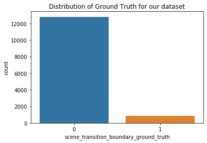

```python
# Countplot to check the distribution of labels in target attribute - 'scene_transition_boundary_ground_truth'
sns.countplot(x="scene_transition_boundary_ground_truth", data=df_data).set_title('Distribution of Ground Truth for our dataset')
```

### Below, we have showcased the box plots for the first feature for all four semantic features - place, cast, action, audio - against the target feature - scene_transition_boundary_ground_truth - to get a sense of impact each semantic feature has on the target feature - scene transition True / False values

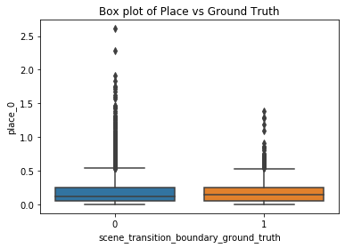

```python
# Boxplot of place attribute vs target attribute ground truth
sns.boxplot(y="place_0", x="scene_transition_boundary_ground_truth", data=df_data)
plt.title("Box plot of Place vs Ground Truth")
```

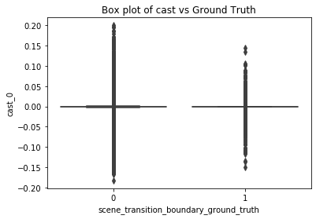

```python
# Boxplot of cast attribute vs target attribute ground truth
sns.boxplot(y="cast_0", x="scene_transition_boundary_ground_truth", data=df_data)
plt.title("Box plot of cast vs Ground Truth")
```

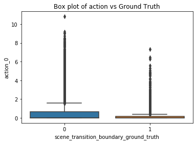

```python
# Boxplot of action attribute vs target attribute ground truth
sns.boxplot(y="action_0", x="scene_transition_boundary_ground_truth", data=df_data)
plt.title("Box plot of action vs Ground Truth")
```

#### Box plot for the first audio shot feature vs the target ground truth feature shows us that when the scene transitions take place, the mean value for audio shot features is close to 0

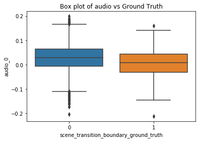

```python
# Boxplot of audio attribute vs target attribute ground truth
sns.boxplot(y="audio_0", x="scene_transition_boundary_ground_truth", data=df_data)
plt.title("Box plot of audio vs Ground Truth")
```

## 2.3) Feature Engineering - Handling imbalanced dataset using undersampling technique

- As we can see from the below distribution, the dataset is highly imbalanced with respect to the target feature - ground feature
- To handle this imbalanced dataset problem, we have used the undersampling technique
- We have brought down the count of overrepresented classes to match the count of underrepresented classes using a random sample which has been extracted from the original dataset

```python
# count of values in target feature before under sampling
df_data['scene_transition_boundary_ground_truth'].value_counts()
```

```
0    12802
1      884
Name: scene_transition_boundary_ground_truth, dtype: int64
```

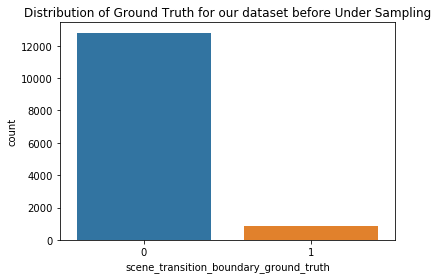

```python
# Countplot to check the distribution of labels in target attribute before performing under sampling
sns.countplot(x="scene_transition_boundary_ground_truth", data=df_data).set_title('Distribution of Ground Truth for our dataset before Under Sampling')
```

```python
# implementing under sampling on target attribute
sample_df = df_data.groupby('scene_transition_boundary_ground_truth').apply(lambda x: x.sample(n=884)).reset_index(drop = True)
```

```python
# printing shape of undersampled dataset
sample_df.shape
```

```
(1768, 3588)
```

```python
# checking value counts for target attribute after under sampling
sample_df['scene_transition_boundary_ground_truth'].value_counts()
```

```
1    884
0    884
Name: scene_transition_boundary_ground_truth, dtype: int64
```

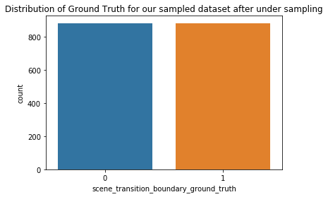

```python
# Countplot to check the distribution of labels in target attribute after performing under sampling
sns.countplot(x="scene_transition_boundary_ground_truth", data=sample_df).set_title('Distribution of Ground Truth for our sampled dataset after under sampling')
```

## 2.4) Feature Engineering: Introducing Single Lag for each of the semantic feature

- We believe, to predict the shot boundary, the model needs to understand the difference in patterns of the first and the second shot. So, we have created new features with a single lag for each of the semanctic features

```python
# creating dataframes for introducing lags
sample_lag_df_features = sample_df.drop('scene_transition_boundary_ground_truth', axis=1)
sample_lag_df_target = sample_df['scene_transition_boundary_ground_truth']
```

```python
# introducing lags
lags = range(1, 2)
```

```python
# introducing lags
sample_lag_df_features = sample_lag_df_features.assign(**{
    '{}_lag{}'.format(col, t): sample_lag_df_features[col].shift(t)
    for t in lags
    for col in sample_lag_df_features
})
```

```python
# print head of lagged features
sample_lag_df_features.head()
```

|  | place_0 | place_1 | place_2 | place_3 | place_4 | place_5 | place_6 | place_7 | place_8 | place_9 | ... | audio_505_lag1 | audio_506_lag1 | audio_507_lag1 | audio_508_lag1 | audio_509_lag1 | audio_510_lag1 | audio_511_lag1 | shot_end_frame_lag1 | imdb_id_lag1 | scene_transition_boundary_prediction_lag1 |
| --- | --- | --- | --- | --- | --- | --- | --- | --- | --- | --- | --- | --- | --- | --- | --- | --- | --- | --- | --- | --- | --- |
| 0 | 1.015974 | 0.080442 | 0.718419 | 0.425282 | 0.263519 | 0.131347 | 0.619938 | 1.058933 | 0.284538 | 0.352986 | ... | NaN | NaN | NaN | NaN | NaN | NaN | NaN | NaN | NaN | NaN |
| 1 | 0.213749 | 0.332000 | 0.142420 | 0.727351 | 1.186241 | 1.012456 | 0.181527 | 0.368308 | 0.181662 | 0.329417 | ... | -0.021092 | -0.040983 | -0.005209 | -0.015622 | -0.018565 | -0.040693 | -0.043941 | 63641.0 | tt0063442 | 0.0305633544921875 |
| 2 | 0.354128 | 0.639288 | 1.112100 | 0.059886 | 0.751858 | 0.348241 | 1.329029 | 0.355326 | 0.109889 | 0.464578 | ... | 0.013504 | -0.058221 | 0.026287 | -0.049740 | -0.009002 | -0.028123 | -0.012860 | 102425.0 | tt0088944 | 0.01959228515625 |
| 3 | 0.018294 | 0.468095 | 0.124534 | 0.133849 | 0.156831 | 0.167848 | 0.417986 | 0.357649 | 0.140577 | 0.463034 | ... | 0.009372 | -0.039274 | -0.022958 | -0.014214 | 0.008701 | -0.037563 | -0.038954 | 43934.0 | tt0052357 | 0.0309906005859375 |
| 4 | 0.035420 | 0.968036 | 1.128158 | 0.047241 | 0.629714 | 0.197887 | 1.623528 | 0.578731 | 0.083444 | 0.565098 | ... | -0.011584 | -0.000107 | -0.004316 | -0.009532 | -0.011385 | 0.007650 | 0.013937 | 138006.0 | tt0086190 | 0.08282470703125 |

5 rows × 7174 columns

```python
# creating lagged dataframe
sample_lag_df = pd.concat([sample_lag_df_features, sample_lag_df_target], axis=1)
```

```python
# print head of final lagged dataframe
sample_lag_df.head()
```

|  | place_0 | place_1 | place_2 | place_3 | place_4 | place_5 | place_6 | place_7 | place_8 | place_9 | ... | audio_506_lag1 | audio_507_lag1 | audio_508_lag1 | audio_509_lag1 | audio_510_lag1 | audio_511_lag1 | shot_end_frame_lag1 | imdb_id_lag1 | scene_transition_boundary_prediction_lag1 | scene_transition_boundary_ground_truth |
| --- | --- | --- | --- | --- | --- | --- | --- | --- | --- | --- | --- | --- | --- | --- | --- | --- | --- | --- | --- | --- | --- |
| 0 | 1.015974 | 0.080442 | 0.718419 | 0.425282 | 0.263519 | 0.131347 | 0.619938 | 1.058933 | 0.284538 | 0.352986 | ... | NaN | NaN | NaN | NaN | NaN | NaN | NaN | NaN | NaN | 0 |
| 1 | 0.213749 | 0.332000 | 0.142420 | 0.727351 | 1.186241 | 1.012456 | 0.181527 | 0.368308 | 0.181662 | 0.329417 | ... | -0.040983 | -0.005209 | -0.015622 | -0.018565 | -0.040693 | -0.043941 | 63641.0 | tt0063442 | 0.0305633544921875 | 0 |
| 2 | 0.354128 | 0.639288 | 1.112100 | 0.059886 | 0.751858 | 0.348241 | 1.329029 | 0.355326 | 0.109889 | 0.464578 | ... | -0.058221 | 0.026287 | -0.049740 | -0.009002 | -0.028123 | -0.012860 | 102425.0 | tt0088944 | 0.01959228515625 | 0 |
| 3 | 0.018294 | 0.468095 | 0.124534 | 0.133849 | 0.156831 | 0.167848 | 0.417986 | 0.357649 | 0.140577 | 0.463034 | ... | -0.039274 | -0.022958 | -0.014214 | 0.008701 | -0.037563 | -0.038954 | 43934.0 | tt0052357 | 0.0309906005859375 | 0 |
| 4 | 0.035420 | 0.968036 | 1.128158 | 0.047241 | 0.629714 | 0.197887 | 1.623528 | 0.578731 | 0.083444 | 0.565098 | ... | -0.000107 | -0.004316 | -0.009532 | -0.011385 | 0.007650 | 0.013937 | 138006.0 | tt0086190 | 0.08282470703125 | 0 |

5 rows × 7175 columns

# 3) Model Building

- Here, we have performed some pre-processing steps required for all of our machine learning models
- We have performed a train-validation split on our training dataset using 70-30 as the size. This will help prevent our models from overfitting and we will also be able to perform hyper-parameter tuning on validation set
- We have created a generic AUC-ROC function which will help us generate the Area Under the Receiver Operating Characrteristic curve for all the models that can predict the probability of the target class labels

#### MODELING APPROACHES:

1) We have implemented the models without using "scene_transition_boundary_prediction" as a predictor without lags

2) We have implemented the models using "scene_transition_boundary_prediction" as a predictor without lags

3) We have implemented the models using "scene_transition_boundary_prediction" as a predictor with lags

4) We have implemented the models without "scene_transition_boundary_prediction" as a predictor with lags

## Evaluation Metrics:

- The F1-score is a way of combining the precision and recall of the model, and it is defined as the harmonic mean of the model’s precision and recall
- Mean Average Precision (mAP) -- AP measures the quality of scene transition predictions in a movie. Specifically, it is the mean of precisions achieved at each threshold, weighted by the increase in recall. Then mAP is the mean of all AP scores
- Mean Maximum IoU (mean Miou) -- Miou measures how well the predicted scenes and the ground-truth scenes overlap in a movie. Then we take the mean of all Miou scores as the final score

### Preparing our data for the models:

```python
# creating the dataset containing boundary prediction feature without lag
df_data_boundary_prediction = sample_df.copy()
```

```python
# creating the dataset not containing the boundary prediction feature without lag
df_data_no_boundary_prediction = sample_df.copy()
```

```python
# creating the dataset containing boundary prediction feature with lag
df_data_boundary_prediction_lag = sample_lag_df.copy()
```

```python
# creating the dataset containing boundary prediction feature without lag
df_data_no_boundary_prediction_lag = sample_lag_df.copy()
```

```python
# remove irrelevant features
del df_data_boundary_prediction['shot_end_frame']
del df_data_boundary_prediction['imdb_id']
```

```python
# remove irrelevant features
del df_data_no_boundary_prediction['shot_end_frame']
del df_data_no_boundary_prediction['imdb_id']
del df_data_no_boundary_prediction['scene_transition_boundary_prediction']
```

```python
# remove irrelevant features
del df_data_boundary_prediction_lag['shot_end_frame']
del df_data_boundary_prediction_lag['imdb_id']
del df_data_boundary_prediction_lag['shot_end_frame_lag1']
del df_data_boundary_prediction_lag['imdb_id_lag1']
```

```python
# remove irrelevant features
del df_data_no_boundary_prediction_lag['shot_end_frame']
del df_data_no_boundary_prediction_lag['imdb_id']
del df_data_no_boundary_prediction_lag['scene_transition_boundary_prediction']
del df_data_no_boundary_prediction_lag['shot_end_frame_lag1']
del df_data_no_boundary_prediction_lag['imdb_id_lag1']
del df_data_no_boundary_prediction_lag['scene_transition_boundary_prediction_lag1']
```

```python
# remove first row containing "NaN" values
df_data_boundary_prediction_lag = df_data_boundary_prediction_lag.iloc[1:]
```

```python
# remove first row containing "NaN" values
df_data_no_boundary_prediction_lag = df_data_no_boundary_prediction_lag.iloc[1:]
```

```python
# print head of dataframe
df_data_no_boundary_prediction_lag.head()
```

|  | place_0 | place_1 | place_2 | place_3 | place_4 | place_5 | place_6 | place_7 | place_8 | place_9 | ... | audio_503_lag1 | audio_504_lag1 | audio_505_lag1 | audio_506_lag1 | audio_507_lag1 | audio_508_lag1 | audio_509_lag1 | audio_510_lag1 | audio_511_lag1 | scene_transition_boundary_ground_truth |
| --- | --- | --- | --- | --- | --- | --- | --- | --- | --- | --- | --- | --- | --- | --- | --- | --- | --- | --- | --- | --- | --- |
| 1 | 0.213749 | 0.332000 | 0.142420 | 0.727351 | 1.186241 | 1.012456 | 0.181527 | 0.368308 | 0.181662 | 0.329417 | ... | -0.023630 | -0.030976 | -0.021092 | -0.040983 | -0.005209 | -0.015622 | -0.018565 | -0.040693 | -0.043941 | 0 |
| 2 | 0.354128 | 0.639288 | 1.112100 | 0.059886 | 0.751858 | 0.348241 | 1.329029 | 0.355326 | 0.109889 | 0.464578 | ... | 0.010023 | -0.029374 | 0.013504 | -0.058221 | 0.026287 | -0.049740 | -0.009002 | -0.028123 | -0.012860 | 0 |
| 3 | 0.018294 | 0.468095 | 0.124534 | 0.133849 | 0.156831 | 0.167848 | 0.417986 | 0.357649 | 0.140577 | 0.463034 | ... | 0.004692 | -0.028627 | 0.009372 | -0.039274 | -0.022958 | -0.014214 | 0.008701 | -0.037563 | -0.038954 | 0 |
| 4 | 0.035420 | 0.968036 | 1.128158 | 0.047241 | 0.629714 | 0.197887 | 1.623528 | 0.578731 | 0.083444 | 0.565098 | ... | -0.012023 | -0.017683 | -0.011584 | -0.000107 | -0.004316 | -0.009532 | -0.011385 | 0.007650 | 0.013937 | 0 |
| 5 | 0.275402 | 0.929346 | 0.527408 | 0.776896 | 0.245464 | 0.098361 | 0.585843 | 0.434912 | 0.000932 | 1.086755 | ... | -0.002463 | -0.028059 | 0.001644 | -0.054553 | 0.004318 | -0.013977 | -0.001678 | -0.064567 | -0.068966 | 0 |

5 rows × 7169 columns

#### ROC function - generic AUC-ROC function which will help us generate the Area Under the Receiver Operating Characteristic curve for all the models that can predict the probability of the target class labels

```python
# Function to plot ROC_AUC_curve

def ROC_AUC_curve(model,model_name="Model"):
    # generate a no skill prediction (majority class)
    ns_probs = [0 for _ in range(len(y_test))]

    # predict probabilities
    lr_probs = model.predict_proba(X_test)
    # keep probabilities for the positive outcome only
    lr_probs = lr_probs[:, 1]
    # calculate scores
    ns_auc = roc_auc_score(y_test, ns_probs)
    lr_auc = roc_auc_score(y_test, lr_probs)
    # summarize scores
    print('No Skill: ROC AUC=%.3f' % (ns_auc))
    print('Model: ROC AUC=%.3f' % (lr_auc))
    # calculate roc curves
    ns_fpr, ns_tpr, _ = roc_curve(y_test, ns_probs)
    lr_fpr, lr_tpr, _ = roc_curve(y_test, lr_probs)
    # plot the roc curve for the model
    plt.figure(figsize=(8,4))
    plt.plot(ns_fpr, ns_tpr, linestyle='--', label='No Skill')
    plt.plot(lr_fpr, lr_tpr, marker='.', label=model_name)
    # axis labels
    plt.xlabel('False Positive Rate')
    plt.ylabel('True Positive Rate')
    # show the legend
    plt.legend()
    # show the plot
    plt.show()
```

```python
# Function to plot ROC_AUC_curve

def ROC_AUC_curve_upgraded(model,model_name="Model"):
    # generate a no skill prediction (majority class)
    ns_probs = [0 for _ in range(len(y_test))]

    # predict probabilities
    lr_probs = model.predict_proba(X_test)
    # keep probabilities for the positive outcome only
    lr_probs = lr_probs
    # calculate scores
    ns_auc = roc_auc_score(y_test, ns_probs)
    lr_auc = roc_auc_score(y_test, lr_probs)
    # summarize scores
    print('No Skill: ROC AUC=%.3f' % (ns_auc))
    print('Decision Tree: ROC AUC=%.3f' % (lr_auc))
    # calculate roc curves
    ns_fpr, ns_tpr, _ = roc_curve(y_test, ns_probs)
    lr_fpr, lr_tpr, _ = roc_curve(y_test, lr_probs)
    # plot the roc curve for the model
    plt.figure(figsize=(8,4))
    plt.plot(ns_fpr, ns_tpr, linestyle='--', label='No Skill')
    plt.plot(lr_fpr, lr_tpr, marker='.', label=model_name)
    # axis labels
    plt.xlabel('False Positive Rate')
    plt.ylabel('True Positive Rate')
    # show the legend
    plt.legend()
    # show the plot
    plt.show()
```

## 3.1) Models without boundary prediction feature and without lags

- Here, we have implemented machine learning models on the dataset that does not contain the feature - scene_transition_boundary_prediction
- The dataset also does not contain the lagged features

### Train-Test Split

```python
# Define X & y for the split
X = df_data_no_boundary_prediction.drop('scene_transition_boundary_ground_truth', axis=1)
y = df_data_no_boundary_prediction['scene_transition_boundary_ground_truth']
```

```python
# 70-30 train-validation split
X_train, X_test, y_train, y_test = train_test_split(X, y, test_size=0.3, random_state=16)
```

## 3.1.1) Random Forest

- We have implemented the Random Forest Claasifier model here
- We have used a 5 folds cross validation grid search to perform the hyper parameter tuning
- After this, we have printed the classification report for our model on training data and testing data in order to get a sense of how well our model is performing in terms of precision, recall, f1-score and accuracy
- We have also generated an AUC-ROC curve for RF model

```python
# initializing the RF model
rf=RandomForestClassifier(random_state=16,n_jobs=-1)
```

#### Hyper-paramater tuning using GridSearch:

- max_depth: This is the maximum depth till which the tree will keep on splitting. It ensures that the tree does not overfit the data
- max_features: The max_features is the number of features that will be used for making a single tree. For eg using "sqrt", the tree uses the square root of the number of total features in the data. Using auto is the same as making use of sqrt. The other values can be specified using the int(number of features to be used less than the total features), log, and a proportion of the features to be used
- min_samples_leaf: The minimum number of samples that should be there in leaf node. If the number is less, then the leaf node is pruned
- min_samples_split: The number of samples that should be present in the node for it to be split further
- n_estimators:This is an important tuning parameter for the Random Forest model. It is the number of trees to be used for predicting the result
- n_jobs: This is a hyper-parameter used for the Grid search. n_jobs=-1 means that the computation will be dispatched on all the CPUs of the computer

```python
# Performing grid search to find the best hyper-parameters
param_grid_rf = {'max_depth': [1,25,10],
            'max_features': ['auto', 'sqrt'],
            'min_samples_leaf': [10,20,30],
             'min_samples_split': [10,20,30],
             'n_estimators': [5,15,30]}
```

```python
# Using 5 fold cross validation and evaluation metric as Recall
grid_rf= GridSearchCV(rf, param_grid_rf, cv=5, scoring='recall', n_jobs=-1, verbose=1)
```

```python
# Fitting RF model
rf_model = grid_rf.fit(X_train, y_train)
```

```
Fitting 5 folds for each of 162 candidates, totalling 810 fits
```

```
[Parallel(n_jobs=-1)]: Using backend LokyBackend with 4 concurrent workers.
[Parallel(n_jobs=-1)]: Done  42 tasks      | elapsed:    5.6s
[Parallel(n_jobs=-1)]: Done 192 tasks      | elapsed:   18.6s
[Parallel(n_jobs=-1)]: Done 442 tasks      | elapsed:   47.7s
[Parallel(n_jobs=-1)]: Done 792 tasks      | elapsed:  1.6min
[Parallel(n_jobs=-1)]: Done 810 out of 810 | elapsed:  1.6min finished
```

```python
# printing the best hyper-parameters
rf_model_best_params = grid_rf.best_params_
print(rf_model_best_params)
```

```
{'max_depth': 25, 'max_features': 'auto', 'min_samples_leaf': 30, 'min_samples_split': 10, 'n_estimators': 30}
```

```python
# Printing classification report for predictions made by model on training dataset
print(classification_report(rf_model.predict(X_train),y_train))
```

```
              precision    recall  f1-score   support

           0       0.85      0.83      0.84       627
           1       0.83      0.85      0.84       610

    accuracy                           0.84      1237
   macro avg       0.84      0.84      0.84      1237
weighted avg       0.84      0.84      0.84      1237
```

```python
# Printing classification report for predictions made by model on validation dataset
print(classification_report(rf_model.predict(X_test),y_test))
```

```
              precision    recall  f1-score   support

           0       0.66      0.64      0.65       275
           1       0.63      0.65      0.64       256

    accuracy                           0.65       531
   macro avg       0.65      0.65      0.65       531
weighted avg       0.65      0.65      0.65       531
```

```python
# Save the trained model as a pickle string.
saved_rf_model = pickle.dumps(rf_model)

# Load the pickled model
rf_from_pickle = pickle.loads(saved_rf_model)
```

#### Generating the AUC-ROC curve for the RF model

- The AUC-ROC score that we get from the graph that we have plotted below tells us that our model is able to distinguish between the ground truths, if they are true or false, almost 72% of the time.
- The score is above 50% which means that the model is not just randomly predicting the probability of a shot boundary being a scene boundary

```
No Skill: ROC AUC=0.500
Model: ROC AUC=0.719
```

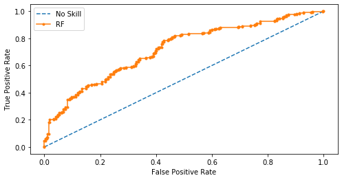

```python
# ROC curve for RF model
ROC_AUC_curve(model=rf_model,model_name="RF")
```

#### Feature Importance plot for RF

```python
# creating a new dataframe to store the features and their respective importance values
feature_imp = pd.DataFrame(rf_model.best_estimator_.feature_importances_, index=X_train.columns,
columns=['importance']).sort_values('importance', ascending=False)
feature_imp['features'] = feature_imp.index
feature_imp
```

|  | importance | features |
| --- | --- | --- |
| place_18 | 0.015451 | place_18 |
| place_1438 | 0.012493 | place_1438 |
| audio_237 | 0.011383 | audio_237 |
| cast_305 | 0.010895 | cast_305 |
| place_937 | 0.009876 | place_937 |
| ... | ... | ... |
| place_1305 | 0.000000 | place_1305 |
| place_1306 | 0.000000 | place_1306 |
| place_1307 | 0.000000 | place_1307 |
| place_1308 | 0.000000 | place_1308 |
| audio_511 | 0.000000 | audio_511 |

3584 rows × 2 columns

```python
# top 10 feature imp
feature_imp_10 = feature_imp.head(10)
```

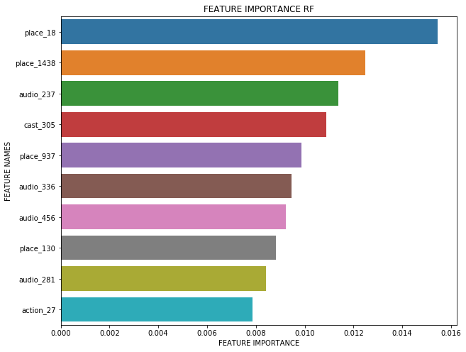

```python
# Plotting Feature Importance graph
plt.figure(figsize=(10,8))

sns.barplot(x=feature_imp_10['importance'], y=feature_imp_10['features'])

plt.title('FEATURE IMPORTANCE RF')
plt.xlabel('FEATURE IMPORTANCE')
plt.ylabel('FEATURE NAMES')
```

## 3.1.2) Logistic Regression

- We have implemented the Logistic Regression classifier model here
- We have used a 5 folds cross validation grid search to perform the hyper-parameter tuning
- After this, we have printed the classification report for our model on training data and testing data in order to get a sense of how well our model is performing in terms of precision, recall, f1-score and accuracy and to see if our model is overfitting on the training data
- We have also generated an AUC-ROC curve for the Logistic Regression model

```python
# initializing the LR model
lr=LogisticRegression(random_state=16,solver="liblinear")
```

#### Hyper-paramater tuning using GridSearch:

- C: This is the cost parameter. It is the inverse of the lambda. Smaller value specify more regularization
- Penalty: The types of penalty that can be used are l1 and l2. The l1 penalty has the characteristics of eliminating features by making its co-efficient 0. The l2 penalty does not eliminate features but it penalizes the effect of less useful features and makes their co-efficient close to 0

```python
# Performing grid search to find the best hyper-parameters
param_grid_lr = {
              'C': [.001,.005,.01,0.1],
              'penalty': ['l1', 'l2']
              }
```

```python
# Using 2 fold cross validation and evaluation metric as Recall
grid_lr = GridSearchCV(lr, param_grid_lr, scoring='recall', cv=5, n_jobs=-1, verbose=1)
```

```python
# Fitting LR model
lr_model = grid_lr.fit(X_train, y_train)
```

```
Fitting 5 folds for each of 8 candidates, totalling 40 fits
```

```
[Parallel(n_jobs=-1)]: Using backend LokyBackend with 4 concurrent workers.
[Parallel(n_jobs=-1)]: Done  40 out of  40 | elapsed:   36.0s finished
```

```python
# printing best hyper-parameters for model
lr_best_params = grid_lr.best_params_
print(lr_best_params)
```

```
{'C': 0.001, 'penalty': 'l2'}
```

```python
# Printing classification report for predictions made by model on training dataset
print(classification_report(lr_model.predict(X_train),y_train))
```

```
              precision    recall  f1-score   support

           0       0.71      0.74      0.73       593
           1       0.75      0.73      0.74       644

    accuracy                           0.73      1237
   macro avg       0.73      0.74      0.73      1237
weighted avg       0.74      0.73      0.73      1237
```

```python
# Printing classification report for predictions made by model on test dataset
print(classification_report(lr_model.predict(X_test),y_test))
```

```
              precision    recall  f1-score   support

           0       0.65      0.69      0.67       249
           1       0.71      0.67      0.69       282

    accuracy                           0.68       531
   macro avg       0.68      0.68      0.68       531
weighted avg       0.68      0.68      0.68       531
```

```
No Skill: ROC AUC=0.500
Model: ROC AUC=0.749
```

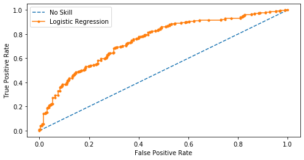

```python
# plot AUC curve
ROC_AUC_curve(model=lr_model,model_name="Logistic Regression")
```

```python
# printing the coefficients of LR model
lr_coefficients=OrderedDict(sorted(zip(X.columns,grid_lr.best_estimator_.coef_[0]),reverse=True,key=lambda x:x[1]))
```

```python
# printing the coefficients
pd.Series(lr_coefficients)
```

```
action_37     0.026856
action_139    0.024578
action_458    0.023680
action_331    0.023321
action_493    0.022469
                ...
place_1381   -0.025979
action_496   -0.026230
place_879    -0.028260
action_69    -0.028269
action_203   -0.029411
Length: 3584, dtype: float64
```

## 3.1.3) Linear Support Vector Machine

- We have implemented the Linear Support Vector Machine model here
- We have used a 5 folds cross validation grid search to perform the hyper parameter tuning
- After this, we have printed the classification report for our model on training and testing data in order to get a sense of how well our model is performing in terms of precision, recall, f1-score and accuracy
- We have not generated an AUC-ROC curve as SVM model does not predict the probability of the target class labels

```python
# initializing the linear SVC model
lsvm = LinearSVC(random_state=16)
```

#### Hyper-paramater tuning using GridSearch:

- C: This is the cost parameter. It is used for regularization and represents the penalty associated with misclassification. Higher C means lower bias but risk of overfitting. It also means higher complexity of decision boundary and higher number of support vectors. Similarly, lower C means higher bias but lower variance
- penalty: This represents the penalty as l1 and l2 regularisation parameter. The l1 and l2 both penalize the points and make the models less susceptible to outliers and improve its overall generalization.
- loss: Specifies the loss function. ‘hinge’ is the standard SVM loss (used e.g. by the SVC class) while ‘squared_hinge’ is the square of the hinge loss.
- n_jobs: This is a hyper-parameter used for the Grid search. n_jobs=-1 means that the computation will be dispatched on all the CPUs of the computer

```python
# Performing grid search to find the best hyper-parameters
param_grid_lsvm = { 'C':[.005,.01,.1,.2,.4,.8],
              'penalty':['l1', 'l2'],
              'loss': ['hinge', 'square_hinge']
              }
```

```python
# Using 5 fold cross validation and evaluation metric as Recall
grid_lsvm = GridSearchCV(lsvm, param_grid_lsvm, cv=5, scoring='recall', n_jobs=-1, verbose=1)
```

```python
# Fitting linear svc model
lsvm_model = grid_lsvm.fit(X_train, y_train)
```

```
Fitting 5 folds for each of 24 candidates, totalling 120 fits
```

```
[Parallel(n_jobs=-1)]: Using backend LokyBackend with 4 concurrent workers.
[Parallel(n_jobs=-1)]: Done  42 tasks      | elapsed:   14.7s
[Parallel(n_jobs=-1)]: Done 120 out of 120 | elapsed:  1.2min finished
```

```python
# printing the best hyper-parameters
lsvm_best_params = grid_lsvm.best_params_
print(lsvm_best_params)
```

```
{'C': 0.005, 'loss': 'hinge', 'penalty': 'l2'}
```

```python
# Printing classification report for predictions made by model on training dataset
print(classification_report(lsvm_model.predict(X_train),y_train))
```

```
              precision    recall  f1-score   support

           0       0.83      0.85      0.84       601
           1       0.86      0.84      0.85       636

    accuracy                           0.84      1237
   macro avg       0.84      0.85      0.84      1237
weighted avg       0.85      0.84      0.84      1237
```

```python
# Printing classification report for predictions made by model on validation dataset
print(classification_report(lsvm_model.predict(X_test),y_test))
```

```
              precision    recall  f1-score   support

           0       0.65      0.73      0.69       238
           1       0.76      0.68      0.72       293

    accuracy                           0.70       531
   macro avg       0.70      0.71      0.70       531
weighted avg       0.71      0.70      0.71       531
```

## 3.1.4) Gradient Boosting Machine

- We have implemented the Gradient Boosting Machine Classifier model here
- We have used a 3 folds cross validation grid search to perform the hyper parameter tuning
- After this, we have printed the classification report for our model on training and testing data in order to get a sense of how well our model is performing in terms of precision, recall, f1-score and accuracy
- We have also generated an AUC-ROC curve for GBM model

```python
# initializing the GBM model
gbm=GradientBoostingClassifier(random_state=16)
```

### Hyper-paramater tuning using GridSearch:

- max_features: The max_features is the number of features that will be used for making a single tree. For eg using "sqrt", the tree uses the square root of the number of total features in the data. Using auto is the same as making use of sqrt. The other values can be specified using the int(number of features to be used less than the total features), log, and a proportion of the features to be used
- n_estimators:This is an important tuning parameter for the Gradient Boost model. It is the number of trees to be used for predicting the result
- subsample: The proportion of sample to be used for training individual base learner
- max_depth: This is the maximum depth till which the tree will keep on splitting. It ensures that the tree does not overfit the data
- min_samples_split: The number of samples that should be present in the node for it to be split further
- min_samples_leaf: The minimum number of samples that should be there in leaf node. If the number is less, then the leaf node is pruned
- n_jobs: This is a hyper-parameter used for the Grid search. n_jobs=-1 means that the computation will be dispatched on all the CPUs of the computer

```python
# Performing grid search to find the best hyper-parameters
param_grid_gbm = {'max_features': ['auto','sqrt'],
              'n_estimators': [20,30,40],
              'subsample':[0.6,0.8,0.9],
              'max_depth': [1,5,20,],
              'min_samples_split':[25,35,50],
              'min_samples_leaf':[10,30,50]}
```

```python
# Using 3 fold cross validation and evaluation metric as Recall
grid_gbm= GridSearchCV(gbm, param_grid_gbm, cv=3, scoring='recall', n_jobs=-1, verbose=1)
```

```python
# Fitting GBM model
gbm_model = grid_gbm.fit(X_train, y_train)
```

```
Fitting 3 folds for each of 486 candidates, totalling 1458 fits
```

```
[Parallel(n_jobs=-1)]: Using backend LokyBackend with 4 concurrent workers.
[Parallel(n_jobs=-1)]: Done  42 tasks      | elapsed:  1.3min
[Parallel(n_jobs=-1)]: Done 192 tasks      | elapsed:  5.7min
[Parallel(n_jobs=-1)]: Done 442 tasks      | elapsed:  7.3min
[Parallel(n_jobs=-1)]: Done 792 tasks      | elapsed: 34.0min
[Parallel(n_jobs=-1)]: Done 1242 tasks      | elapsed: 64.8min
[Parallel(n_jobs=-1)]: Done 1458 out of 1458 | elapsed: 65.5min finished
```

```python
# printing the best hyper-parameters
gbm_best_params = grid_gbm.best_params_
print(gbm_best_params)
```

```
{'max_depth': 20, 'max_features': 'sqrt', 'min_samples_leaf': 10, 'min_samples_split': 35, 'n_estimators': 40, 'subsample': 0.8}
```

```python
# Printing classification report for predictions made by model on validation dataset
print(classification_report(gbm_model.predict(X_test),y_test))
```

```
              precision    recall  f1-score   support

           0       0.65      0.70      0.67       248
           1       0.72      0.67      0.69       283

    accuracy                           0.68       531
   macro avg       0.68      0.68      0.68       531
weighted avg       0.68      0.68      0.68       531
```

```
No Skill: ROC AUC=0.500
Model: ROC AUC=0.728
```

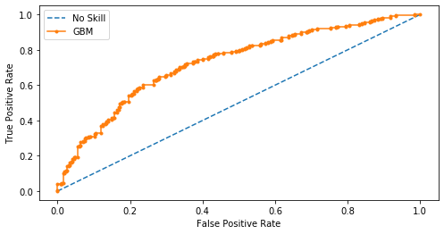

```python
# printing AUC curve for GBM model
ROC_AUC_curve(model=gbm_model,model_name="GBM")
```

```python
# creating a new dataframe to store the features and their respective importance values
feature_imp = pd.DataFrame(gbm_model.best_estimator_.feature_importances_, index=X_train.columns,
columns=['importance']).sort_values('importance', ascending=False)
feature_imp['features'] = feature_imp.index
feature_imp
```

|  | importance | features |
| --- | --- | --- |
| audio_491 | 0.009655 | audio_491 |
| audio_391 | 0.009378 | audio_391 |
| cast_352 | 0.008400 | cast_352 |
| place_1030 | 0.007420 | place_1030 |
| place_1376 | 0.006501 | place_1376 |
| ... | ... | ... |
| place_1583 | 0.000000 | place_1583 |
| place_1584 | 0.000000 | place_1584 |
| place_1586 | 0.000000 | place_1586 |
| place_1587 | 0.000000 | place_1587 |
| audio_511 | 0.000000 | audio_511 |

3584 rows × 2 columns

```python
# top 10 features
feature_imp_10 = feature_imp.head(10)
```

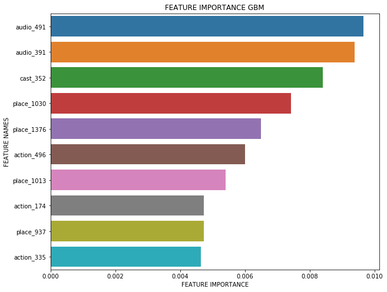

```python
# Plotting Feature Importance graph
plt.figure(figsize=(10,8))

sns.barplot(x=feature_imp_10['importance'], y=feature_imp_10['features'])

plt.title('FEATURE IMPORTANCE GBM')
plt.xlabel('FEATURE IMPORTANCE')
plt.ylabel('FEATURE NAMES')
```

## 3.1.5) ANN - Artificial Neural Network - 1 Hidden Layer

- We have implemented the Artificial Neural Network model with 1 hidden layers here
- The ANN1 model contains an initial sequential layer followed by the dense hidden layer using activation function as 'relu' and 20 nodes followed by dense output layer that uses 'sigmoid' as the activation function in order to predict the binary labels for output class.
- The input shape is the total number of features present in the training data i.e. 3584
- The hidden layer contains 20 nodes of perceptrons
- We have used the loss function as 'binary_crossentropy', optimizer as 'adam' and metrics as 'accuracy' to implement a deep learning network with 1 hidden layers
- We have used epochs=30 and batch_size=20 for the hyperparameter tuning of the model and have calculated the loss and accuracy for both train and testing data for each epoch
- After this, we have printed the classification report for our model on training data, validation data in order to get a sense of how well our model is performing in terms of precision, recall, f1-score and accuracy
- We have generated an AUC-ROC curve as ANN1 model that predicts the probability of the target class labels

```python
# initializing the ANN1 model
ann1 = Sequential()
ann1.add(Dense(20, activation='relu', input_shape=(3584,)))
ann1.add(Dense(1, activation='sigmoid', input_shape=(20,)))
```

```python
# compiling ANN1 model
ann1.compile(loss='binary_crossentropy', optimizer='adam', metrics=['accuracy'])
```

```python
# fitting ANN1 model
ann1.fit(X_train, y_train, epochs=30, batch_size=20, verbose=1,validation_data=(X_test,y_test))
```

```
Train on 1237 samples, validate on 531 samples
```

```
<keras.callbacks.callbacks.History at 0x7fa197bed510>
```

```python
# Printing classification report for predictions made by model on training dataset
print(classification_report(y_true=y_train,y_pred=(ann1.predict(X_train)>0.5).astype(int)))
```

```
              precision    recall  f1-score   support

           0       0.96      0.95      0.96       617
           1       0.96      0.96      0.96       620

    accuracy                           0.96      1237
   macro avg       0.96      0.96      0.96      1237
weighted avg       0.96      0.96      0.96      1237
```

```python
# Printing classification report for predictions made by model on validation dataset
print(classification_report(y_true=y_test,y_pred=(ann1.predict(X_test)>0.5).astype(int)))
```

```
              precision    recall  f1-score   support

           0       0.70      0.65      0.67       267
           1       0.67      0.72      0.70       264

    accuracy                           0.69       531
   macro avg       0.69      0.69      0.69       531
weighted avg       0.69      0.69      0.69       531
```

```
No Skill: ROC AUC=0.500
Decision Tree: ROC AUC=0.728
```

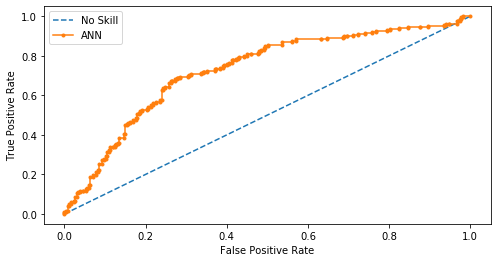

```python
# plot AUC curve
ROC_AUC_curve_upgraded(model=ann1,model_name="ANN")
```

## 3.1.6) Conclusion for Models without boundary prediction feature and without lag

```python
# Creating a summary table for the model names, their recall, auc, accuracy scores and their best hyper parameters
best_models_1 = pd.DataFrame({"Algorithm":["LR","RF","ANN","GBM","LSVM"], "Recall":[67,65,72,67,68],
                            "AUC":[74.9,71.9,72.8,72.8,'-'], 'Accuracy':[68,65,69,68,70],
                            'Precision':[71,63,67,72,76],
                            'F1-Score':[69,64,70,69,72]
                            })
```

```python
# Printing the best_models summary table sorted by F1-scores
best_models_1.sort_values(by="F1-Score",ascending=False)
```

|  | Algorithm | Recall | AUC | Accuracy | Precision | F1-Score |
| --- | --- | --- | --- | --- | --- | --- |
| 4 | LSVM | 68 | - | 70 | 76 | 72 |
| 2 | ANN | 72 | 72.8 | 69 | 67 | 70 |
| 0 | LR | 67 | 74.9 | 68 | 71 | 69 |
| 3 | GBM | 67 | 72.8 | 68 | 72 | 69 |
| 1 | RF | 65 | 71.9 | 65 | 63 | 64 |

## 3.2) Models with boundary prediction feature and without lags

- Here, we have implemented machine learning models on the dataset that contain the feature - scene_transition_boundary_prediction
- The dataset also does not contain the lagged features

### Train-Test Split

```python
# Define X & y for the split
X = df_data_boundary_prediction.drop('scene_transition_boundary_ground_truth', axis=1)
y = df_data_boundary_prediction['scene_transition_boundary_ground_truth']
```

```python
# 70-30 train-validation split
X_train, X_test, y_train, y_test = train_test_split(X, y, test_size=0.3, random_state=16)
```

## 3.2.1) Random Forest

- We have implemented the Random Forest Clasifier model here
- We have used a 5 folds cross validation grid search to perform the hyper parameter tuning
- After this, we have printed the classification report for our model on training data and testing data in order to get a sense of how well our model is performing in terms of precision, recall, f1-score and accuracy
- We have also generated an AUC-ROC curve for RF model

```python
# initializing the RF model
rf=RandomForestClassifier(random_state=16,n_jobs=-1)
```

#### Hyper-paramater tuning using GridSearch:

- max_depth: This is the maximum depth till which the tree will keep on splitting. It ensures that the tree does not overfit the data
- max_features: The max_features is the number of features that will be used for making a single tree. For eg using "sqrt", the tree uses the square root of the number of total features in the data. Using auto is the same as making use of sqrt. The other values can be specified using the int(number of features to be used less than the total features), log, and a proportion of the features to be used
- min_samples_leaf: The minimum number of samples that should be there in leaf node. If the number is less, then the leaf node is pruned
- min_samples_split: The number of samples that should be present in the node for it to be split further
- n_estimators:This is an important tuning parameter for the Random Forest model. It is the number of trees to be used for predicting the result
- n_jobs: This is a hyper-parameter used for the Grid search. n_jobs=-1 means that the computation will be dispatched on all the CPUs of the computer

```python
# Performing grid search to find the best hyper-parameters
param_grid_rf = {'max_depth': [1,25,10],
            'max_features': ['auto', 'sqrt'],
            'min_samples_leaf': [10,20,30],
             'min_samples_split': [10,20,30],
             'n_estimators': [5,15,30]}
```

```python
# Using 5 fold cross validation and evaluation metric as Recall
grid_rf= GridSearchCV(rf, param_grid_rf, cv=5, scoring='recall', n_jobs=-1, verbose=1)
```

```python
# Fitting RF model
rf_model = grid_rf.fit(X_train, y_train)
```

```
Fitting 5 folds for each of 162 candidates, totalling 810 fits
```

```
[Parallel(n_jobs=-1)]: Using backend LokyBackend with 4 concurrent workers.
[Parallel(n_jobs=-1)]: Done  42 tasks      | elapsed:   16.8s
[Parallel(n_jobs=-1)]: Done 192 tasks      | elapsed:  1.0min
[Parallel(n_jobs=-1)]: Done 442 tasks      | elapsed:  2.3min
[Parallel(n_jobs=-1)]: Done 792 tasks      | elapsed:  3.9min
[Parallel(n_jobs=-1)]: Done 810 out of 810 | elapsed:  4.0min finished
```

```python
# printing the best hyper-parameters
rf_model_best_params = grid_rf.best_params_
print(rf_model_best_params)
```

```
{'max_depth': 1, 'max_features': 'auto', 'min_samples_leaf': 10, 'min_samples_split': 10, 'n_estimators': 5}
```

```python
# Printing classification report for predictions made by model on training dataset
print(classification_report(rf_model.predict(X_train),y_train))
```

```
              precision    recall  f1-score   support

           0       0.47      0.66      0.55       440
           1       0.76      0.59      0.66       797

    accuracy                           0.62      1237
   macro avg       0.62      0.63      0.61      1237
weighted avg       0.66      0.62      0.62      1237
```

```python
# Printing classification report for predictions made by model on validation dataset
print(classification_report(rf_model.predict(X_test),y_test))
```

```
              precision    recall  f1-score   support

           0       0.42      0.61      0.49       182
           1       0.73      0.55      0.63       349

    accuracy                           0.57       531
   macro avg       0.57      0.58      0.56       531
weighted avg       0.62      0.57      0.58       531
```

```
No Skill: ROC AUC=0.500
Model: ROC AUC=0.610
```

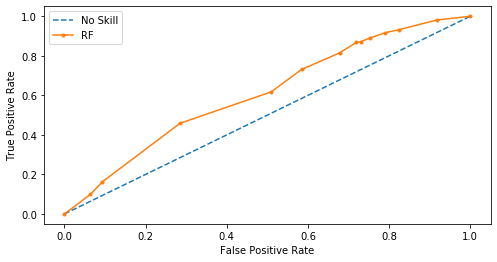

```python
# ROC curve for RF model
ROC_AUC_curve(model=rf_model,model_name="RF")
```

#### Feature Importance plot for RF

```python
# creating a new dataframe to store the features and their respective importance values
feature_imp = pd.DataFrame(rf_model.best_estimator_.feature_importances_, index=X_train.columns,
columns=['importance']).sort_values('importance', ascending=False)
feature_imp['features'] = feature_imp.index
feature_imp
```

|  | importance | features |
| --- | --- | --- |
| audio_60 | 0.2 | audio_60 |
| audio_401 | 0.2 | audio_401 |
| audio_364 | 0.2 | audio_364 |
| audio_336 | 0.2 | audio_336 |
| cast_436 | 0.2 | cast_436 |
| ... | ... | ... |
| place_1199 | 0.0 | place_1199 |
| place_1200 | 0.0 | place_1200 |
| place_1201 | 0.0 | place_1201 |
| place_1202 | 0.0 | place_1202 |
| scene_transition_boundary_prediction | 0.0 | scene_transition_boundary_prediction |

3585 rows × 2 columns

```python
# top 10 features
feature_imp_10 = feature_imp.head(10)
```

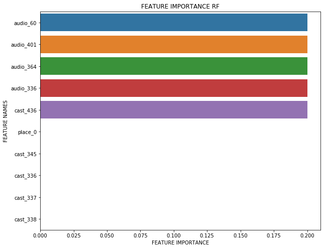

```python
# Plotting Feature Importance graph
plt.figure(figsize=(10,8))

sns.barplot(x=feature_imp_10['importance'], y=feature_imp_10['features'])

plt.title('FEATURE IMPORTANCE RF')
plt.xlabel('FEATURE IMPORTANCE')
plt.ylabel('FEATURE NAMES')
```

## 3.2.2) Logistic Regression

- We have implemented the Logistic Regression classifier model here
- We have used a 5 folds cross validation grid search to perform the hyper-parameter tuning
- After this, we have printed the classification report for our model on training data and testing data in order to get a sense of how well our model is performing in terms of precision, recall, f1-score and accuracy and to see if our model is overfitting on the training data
- We have also generated an AUC-ROC curve for the Logistic Regression model

```python
# initializing the LR model
lr=LogisticRegression(random_state=16,solver="liblinear")
```

#### Hyper-paramater tuning using GridSearch:

- C: This is the cost parameter. It is the inverse of the lambda. Smaller value specify more regularization
- Penalty: The types of penalty that can be used are l1 and l2. The l1 penalty has the characteristics of eliminating features by making its co-efficient 0. The l2 penalty does not eliminate features but it penalizes the effect of less useful features and makes their co-efficient close to 0

```python
# Performing grid search to find the best hyper-parameters
param_grid_lr = {
              'C': [.001,.005,.01,0.1],
              'penalty': ['l1', 'l2']
              }
```

```python
# Using 2 fold cross validation and evaluation metric as Recall
grid_lr = GridSearchCV(lr, param_grid_lr, scoring='recall', cv=5, n_jobs=-1, verbose=1)
```

```python
# Fitting LR model
lr_model = grid_lr.fit(X_train, y_train)
```

```
Fitting 5 folds for each of 8 candidates, totalling 40 fits
```

```
[Parallel(n_jobs=-1)]: Using backend LokyBackend with 4 concurrent workers.
[Parallel(n_jobs=-1)]: Done  40 out of  40 | elapsed:   25.9s finished
```

```python
# printing best hyper-parameters for model
lr_best_params = grid_lr.best_params_
print(lr_best_params)
```

```
{'C': 0.1, 'penalty': 'l1'}
```

```python
# Printing classification report for predictions made by model on training dataset
print(classification_report(lr_model.predict(X_train),y_train))
```

```
              precision    recall  f1-score   support

           0       0.85      0.84      0.85       625
           1       0.84      0.85      0.84       612

    accuracy                           0.84      1237
   macro avg       0.84      0.84      0.84      1237
weighted avg       0.84      0.84      0.84      1237
```

```python
# Printing classification report for predictions made by model on test dataset
print(classification_report(lr_model.predict(X_test),y_test))
```

```
              precision    recall  f1-score   support

           0       0.80      0.84      0.82       255
           1       0.84      0.80      0.82       276

    accuracy                           0.82       531
   macro avg       0.82      0.82      0.82       531
weighted avg       0.82      0.82      0.82       531
```

```
No Skill: ROC AUC=0.500
Model: ROC AUC=0.891
```

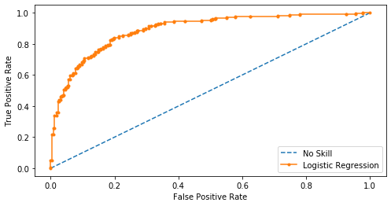

```python
# plot AUC curve
ROC_AUC_curve(model=lr_model,model_name="Logistic Regression")
```

```python
# printing the coefficients of LR model
lr_coefficients=OrderedDict(sorted(zip(X.columns,grid_lr.best_estimator_.coef_[0]),reverse=True,key=lambda x:x[1]))
```

```python
# printing the coefficients
pd.Series(lr_coefficients)
```

```
scene_transition_boundary_prediction    4.004887
place_1346                              0.127605
action_493                              0.120411
action_137                              0.114661
action_36                               0.094529
                                          ...
place_1791                             -0.222312
place_1381                             -0.225811
place_198                              -0.237374
place_1008                             -0.265306
place_879                              -0.273323
Length: 3585, dtype: float64
```

## 3.2.3) Linear Support Vector Machine

- We have implemented the Linear Support Vector Machine model here
- We have used a 5 folds cross validation grid search to perform the hyper parameter tuning
- After this, we have printed the classification report for our model on training and testing data in order to get a sense of how well our model is performing in terms of precision, recall, f1-score and accuracy
- We have not generated an AUC-ROC curve as SVM model does not predict the probability of the target class labels

```python
# initializing the linear SVC model
lsvm = LinearSVC(random_state=16)
```

#### Hyper-paramater tuning using GridSearch:

- C: This is the cost parameter. It is used for regularization and represents the penalty associated with misclassification. Higher C means lower bias but risk of overfitting. It also means higher complexity of decision boundary and higher number of support vectors. Similarly, lower C means higher bias but lower variance
- penalty: This represents the penalty as l1 and l2 regularisation parameter. The l1 and l2 both penalize the points and make the models less susceptible to outliers and improve its overall generalization.
- loss: Specifies the loss function. ‘hinge’ is the standard SVM loss (used e.g. by the SVC class) while ‘squared_hinge’ is the square of the hinge loss.
- n_jobs: This is a hyper-parameter used for the Grid search. n_jobs=-1 means that the computation will be dispatched on all the CPUs of the computer

```python
# Performing grid search to find the best hyper-parameters
param_grid_lsvm = { 'C':[.005,.01,.1,.2,.4,.8],
              'penalty':['l1', 'l2'],
              'loss': ['hinge', 'square_hinge']
              }
```

```python
# Using 5 fold cross validation and evaluation metric as Recall
grid_lsvm = GridSearchCV(lsvm, param_grid_lsvm, cv=5, scoring='recall', n_jobs=-1, verbose=1)
```

```python
# Fitting linear svc model
lsvm_model = grid_lsvm.fit(X_train, y_train)
```

```
Fitting 5 folds for each of 24 candidates, totalling 120 fits
```

```
[Parallel(n_jobs=-1)]: Using backend LokyBackend with 4 concurrent workers.
[Parallel(n_jobs=-1)]: Done  42 tasks      | elapsed:   29.9s
[Parallel(n_jobs=-1)]: Done 120 out of 120 | elapsed:  1.7min finished
```

```python
# printing the best hyper-parameters
lsvm_best_params = grid_lsvm.best_params_
print(lsvm_best_params)
```

```
{'C': 0.005, 'loss': 'hinge', 'penalty': 'l2'}
```

```python
# Printing classification report for predictions made by model on training dataset
print(classification_report(lsvm_model.predict(X_train),y_train))
```

```
              precision    recall  f1-score   support

           0       0.86      0.90      0.88       590
           1       0.90      0.87      0.88       647

    accuracy                           0.88      1237
   macro avg       0.88      0.88      0.88      1237
weighted avg       0.88      0.88      0.88      1237
```

```python
# Printing classification report for predictions made by model on validation dataset
print(classification_report(lsvm_model.predict(X_test),y_test))
```

```
              precision    recall  f1-score   support

           0       0.70      0.78      0.74       240
           1       0.80      0.73      0.76       291

    accuracy                           0.75       531
   macro avg       0.75      0.76      0.75       531
weighted avg       0.76      0.75      0.75       531
```

## 3.2.4) ANN - Artificial Neural Network - 1 Hidden Layer

- We have implemented the Artificial Neural Network model with 1 hidden layers here
- The ANN1 model contains an initial sequential layer followed by the dense hidden layer using activation function as 'relu' and 20 nodes followed by dense output layer that uses 'sigmoid' as the activation function in order to predict the binary labels for output class.
- The input shape is the total number of features present in the training data i.e. 3585
- The hidden layer contains 20 nodes of perceptrons
- We have used the loss function as 'binary_crossentropy', optimizer as 'adam' and metrics as 'accuracy' to implement a deep learning network with 1 hidden layers
- We have used epochs=30 and batch_size=20 for the hyperparameter tuning of the model and have calculated the loss and accuracy for both train and testing data for each epoch
- After this, we have printed the classification report for our model on training data, validation data in order to get a sense of how well our model is performing in terms of precision, recall, f1-score and accuracy
- We have generated an AUC-ROC curve as ANN1 model that predicts the probability of the target class labels

```python
# initializing the ANN1 model
ann1 = Sequential()
ann1.add(Dense(20, activation='relu', input_shape=(3585,)))
ann1.add(Dense(1, activation='sigmoid', input_shape=(20,)))
```

```python
# compiling ANN1 model
ann1.compile(loss='binary_crossentropy', optimizer='adam', metrics=['accuracy'])
```

```python
# fitting ANN1 model
ann1.fit(X_train, y_train, epochs=30, batch_size=20, verbose=1,validation_data=(X_test,y_test))
```

```
Train on 1237 samples, validate on 531 samples
```

```
<keras.callbacks.callbacks.History at 0x7fa1e0563f50>
```

```python
# Printing classification report for predictions made by model on training dataset
print(classification_report(y_true=y_train,y_pred=(ann1.predict(X_train)>0.5).astype(int)))
```

```
              precision    recall  f1-score   support

           0       0.95      0.91      0.93       617
           1       0.91      0.95      0.93       620

    accuracy                           0.93      1237
   macro avg       0.93      0.93      0.93      1237
weighted avg       0.93      0.93      0.93      1237
```

```python
# Printing classification report for predictions made by model on validation dataset
print(classification_report(y_true=y_test,y_pred=(ann1.predict(X_test)>0.5).astype(int)))
```

```
              precision    recall  f1-score   support

           0       0.74      0.66      0.70       267
           1       0.69      0.77      0.73       264

    accuracy                           0.71       531
   macro avg       0.72      0.71      0.71       531
weighted avg       0.72      0.71      0.71       531
```

```
No Skill: ROC AUC=0.500
Decision Tree: ROC AUC=0.770
```

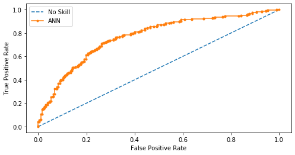

```python
# plot AUC curve
ROC_AUC_curve_upgraded(model=ann1,model_name="ANN")
```

## 3.2.5) Conclusion for Models with boundary prediction as feature and no lags

```python
# Creating a summary table for the model names, their recall, auc, accuracy scores and their best hyper parameters
best_models_2 = pd.DataFrame({"Algorithm":["LR","RF","ANN","LSVM"], "Recall":[80,55,77,73],
                            "AUC":[82,61,77,'-'], 'Accuracy':[82,57,71,75],
                            'Precision':[84,73,69,80],
                            'F1-Score':[82,63,73,76]
                            })
```

```python
# Printing the best_models summary table sorted by F1-scores
best_models_2.sort_values(by="F1-Score",ascending=False)
```

|  | Algorithm | Recall | AUC | Accuracy | Precision | F1-Score |
| --- | --- | --- | --- | --- | --- | --- |
| 0 | LR | 80 | 82 | 82 | 84 | 82 |
| 3 | LSVM | 73 | - | 75 | 80 | 76 |
| 2 | ANN | 77 | 77 | 71 | 69 | 73 |
| 1 | RF | 55 | 61 | 57 | 73 | 63 |

## 3.3) Models with boundary prediction feature and with single lag for all semantic feature

- Here, we have implemented machine learning models on the dataset that contain the feature - scene_transition_boundary_prediction
- The dataset also contains the lagged features

### Train-Test Split

```python
# Define X & y for the split
X = df_data_boundary_prediction_lag.drop('scene_transition_boundary_ground_truth', axis=1)
y = df_data_boundary_prediction_lag['scene_transition_boundary_ground_truth']
```

```python
# print head
X.head()
```

|  | place_0 | place_1 | place_2 | place_3 | place_4 | place_5 | place_6 | place_7 | place_8 | place_9 | ... | audio_503_lag1 | audio_504_lag1 | audio_505_lag1 | audio_506_lag1 | audio_507_lag1 | audio_508_lag1 | audio_509_lag1 | audio_510_lag1 | audio_511_lag1 | scene_transition_boundary_prediction_lag1 |
| --- | --- | --- | --- | --- | --- | --- | --- | --- | --- | --- | --- | --- | --- | --- | --- | --- | --- | --- | --- | --- | --- |
| 1 | 0.213749 | 0.332000 | 0.142420 | 0.727351 | 1.186241 | 1.012456 | 0.181527 | 0.368308 | 0.181662 | 0.329417 | ... | -0.023630 | -0.030976 | -0.021092 | -0.040983 | -0.005209 | -0.015622 | -0.018565 | -0.040693 | -0.043941 | 0.0305633544921875 |
| 2 | 0.354128 | 0.639288 | 1.112100 | 0.059886 | 0.751858 | 0.348241 | 1.329029 | 0.355326 | 0.109889 | 0.464578 | ... | 0.010023 | -0.029374 | 0.013504 | -0.058221 | 0.026287 | -0.049740 | -0.009002 | -0.028123 | -0.012860 | 0.01959228515625 |
| 3 | 0.018294 | 0.468095 | 0.124534 | 0.133849 | 0.156831 | 0.167848 | 0.417986 | 0.357649 | 0.140577 | 0.463034 | ... | 0.004692 | -0.028627 | 0.009372 | -0.039274 | -0.022958 | -0.014214 | 0.008701 | -0.037563 | -0.038954 | 0.0309906005859375 |
| 4 | 0.035420 | 0.968036 | 1.128158 | 0.047241 | 0.629714 | 0.197887 | 1.623528 | 0.578731 | 0.083444 | 0.565098 | ... | -0.012023 | -0.017683 | -0.011584 | -0.000107 | -0.004316 | -0.009532 | -0.011385 | 0.007650 | 0.013937 | 0.08282470703125 |
| 5 | 0.275402 | 0.929346 | 0.527408 | 0.776896 | 0.245464 | 0.098361 | 0.585843 | 0.434912 | 0.000932 | 1.086755 | ... | -0.002463 | -0.028059 | 0.001644 | -0.054553 | 0.004318 | -0.013977 | -0.001678 | -0.064567 | -0.068966 | 0.6748046875 |

5 rows × 7170 columns

```python
# print shape
X.shape
```

```
(1767, 7170)
```

```python
# 70-30 train-validation split
X_train, X_test, y_train, y_test = train_test_split(X, y, test_size=0.3, random_state=16)
```

## 3.3.1) Random Forest

- We have implemented the Random Forest Clasifier model here
- We have used a 3 folds cross validation grid search to perform the hyper parameter tuning
- After this, we have printed the classification report for our model on training data and testing data in order to get a sense of how well our model is performing in terms of precision, recall, f1-score and accuracy
- We have also generated an AUC-ROC curve for RF model

```python
# initializing the RF model
rf=RandomForestClassifier(random_state=16,n_jobs=-1)
```

#### Hyper-paramater tuning using GridSearch:

- max_depth: This is the maximum depth till which the tree will keep on splitting. It ensures that the tree does not overfit the data
- max_features: The max_features is the number of features that will be used for making a single tree. For eg using "sqrt", the tree uses the square root of the number of total features in the data. Using auto is the same as making use of sqrt. The other values can be specified using the int(number of features to be used less than the total features), log, and a proportion of the features to be used
- min_samples_leaf: The minimum number of samples that should be there in leaf node. If the number is less, then the leaf node is pruned
- min_samples_split: The number of samples that should be present in the node for it to be split further
- n_estimators:This is an important tuning parameter for the Random Forest model. It is the number of trees to be used for predicting the result
- n_jobs: This is a hyper-parameter used for the Grid search. n_jobs=-1 means that the computation will be dispatched on all the CPUs of the computer

```python
# Performing grid search to find the best hyper-parameters
param_grid_rf = {'max_depth': [1,25,10],
            'max_features': ['auto', 'sqrt'],
            'min_samples_leaf': [10,20,30],
             'min_samples_split': [10,20,30],
             'n_estimators': [5,15,30]}
```

```python
# Using 5 fold cross validation and evaluation metric as Recall
grid_rf= GridSearchCV(rf, param_grid_rf, cv=3, scoring='recall', n_jobs=-1, verbose=1)
```

```python
# Fitting RF model
rf_model = grid_rf.fit(X_train, y_train)
```

```
Fitting 3 folds for each of 162 candidates, totalling 486 fits
```

```
[Parallel(n_jobs=-1)]: Using backend LokyBackend with 4 concurrent workers.
[Parallel(n_jobs=-1)]: Done  42 tasks      | elapsed:   22.1s
[Parallel(n_jobs=-1)]: Done 192 tasks      | elapsed:  1.5min
[Parallel(n_jobs=-1)]: Done 442 tasks      | elapsed:  3.4min
[Parallel(n_jobs=-1)]: Done 486 out of 486 | elapsed:  3.9min finished
```

```python
# printing the best hyper-parameters
rf_model_best_params = grid_rf.best_params_
print(rf_model_best_params)
```

```
{'max_depth': 25, 'max_features': 'auto', 'min_samples_leaf': 10, 'min_samples_split': 30, 'n_estimators': 30}
```

```python
# Printing classification report for predictions made by model on training dataset
print(classification_report(rf_model.predict(X_train),y_train))
```

```
              precision    recall  f1-score   support

           0       0.96      0.97      0.96       613
           1       0.97      0.96      0.96       623

    accuracy                           0.96      1236
   macro avg       0.96      0.96      0.96      1236
weighted avg       0.96      0.96      0.96      1236
```

```python
# Printing classification report for predictions made by model on validation dataset
print(classification_report(rf_model.predict(X_test),y_test))
```

```
              precision    recall  f1-score   support

           0       0.75      0.78      0.77       253
           1       0.79      0.77      0.78       278

    accuracy                           0.77       531
   macro avg       0.77      0.77      0.77       531
weighted avg       0.77      0.77      0.77       531
```

```
No Skill: ROC AUC=0.500
Model: ROC AUC=0.857
```

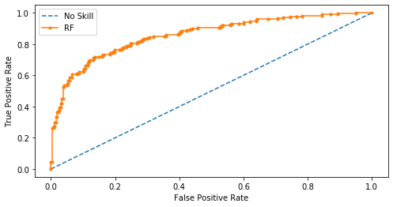

```python
# ROC curve for RF model
ROC_AUC_curve(model=rf_model,model_name="RF")
```

#### Feature Importance plot for RF

```python
# creating a new dataframe to store the features and their respective importance values
feature_imp = pd.DataFrame(rf_model.best_estimator_.feature_importances_, index=X_train.columns,
columns=['importance']).sort_values('importance', ascending=False)
feature_imp['features'] = feature_imp.index
feature_imp
```

|  | importance | features |
| --- | --- | --- |
| scene_transition_boundary_prediction | 0.043436 | scene_transition_boundary_prediction |
| scene_transition_boundary_prediction_lag1 | 0.037150 | scene_transition_boundary_prediction_lag1 |
| cast_510 | 0.008840 | cast_510 |
| audio_336_lag1 | 0.006758 | audio_336_lag1 |
| place_1441_lag1 | 0.006706 | place_1441_lag1 |
| ... | ... | ... |
| action_43 | 0.000000 | action_43 |
| action_42 | 0.000000 | action_42 |
| action_41 | 0.000000 | action_41 |
| action_40 | 0.000000 | action_40 |
| place_0_lag1 | 0.000000 | place_0_lag1 |

7170 rows × 2 columns

```python
# top 10 features
feature_imp_10 = feature_imp.head(10)
```

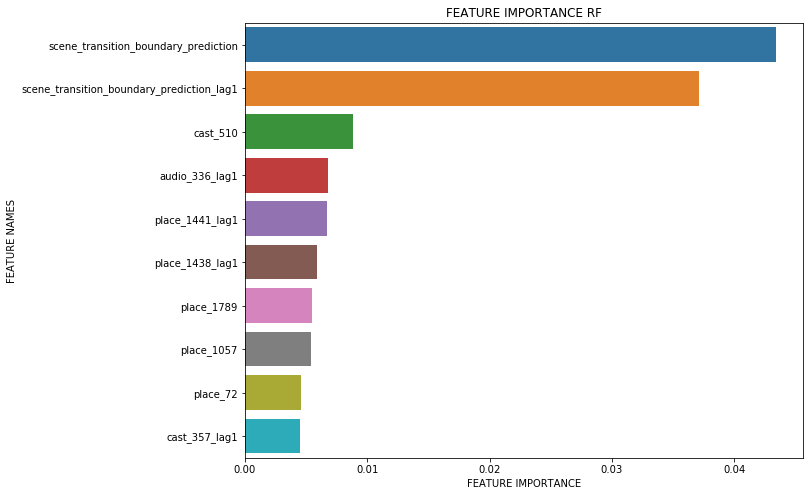

```python
# Plotting Feature Importance graph
plt.figure(figsize=(10,8))

sns.barplot(x=feature_imp_10['importance'], y=feature_imp_10['features'])

plt.title('FEATURE IMPORTANCE RF')
plt.xlabel('FEATURE IMPORTANCE')
plt.ylabel('FEATURE NAMES')
```

## 3.3.2) Logistic Regression

- We have implemented the Logistic Regression classifier model here
- We have used a 5 folds cross validation grid search to perform the hyper-parameter tuning
- After this, we have printed the classification report for our model on training data and testing data in order to get a sense of how well our model is performing in terms of precision, recall, f1-score and accuracy and to see if our model is overfitting on the training data
- We have also generated an AUC-ROC curve for the Logistic Regression model

```python
# initializing the LR model
lr=LogisticRegression(random_state=16,solver="liblinear")
```

#### Hyper-paramater tuning using GridSearch:

- C: This is the cost parameter. It is the inverse of the lambda. Smaller value specify more regularization
- Penalty: The types of penalty that can be used are l1 and l2. The l1 penalty has the characteristics of eliminating features by making its co-efficient 0. The l2 penalty does not eliminate features but it penalizes the effect of less useful features and makes their co-efficient close to 0

```python
# Performing grid search to find the best hyper-parameters
param_grid_lr = {
              'C': [.001,.005,.01,0.1],
              'penalty': ['l1', 'l2']
              }
```

```python
# Using 2 fold cross validation and evaluation metric as Recall
grid_lr = GridSearchCV(lr, param_grid_lr, scoring='recall', cv=5, n_jobs=-1, verbose=1)
```

```python
# Fitting LR model
lr_model = grid_lr.fit(X_train, y_train)
```

```
Fitting 5 folds for each of 8 candidates, totalling 40 fits
```

```
[Parallel(n_jobs=-1)]: Using backend LokyBackend with 4 concurrent workers.
[Parallel(n_jobs=-1)]: Done  40 out of  40 | elapsed:  1.2min finished
```

```python
# printing best hyper-parameters for model
lr_best_params = grid_lr.best_params_
print(lr_best_params)
```

```
{'C': 0.1, 'penalty': 'l1'}
```

```python
# Printing classification report for predictions made by model on training dataset
print(classification_report(lr_model.predict(X_train),y_train))
```

```
              precision    recall  f1-score   support

           0       0.92      0.95      0.93       599
           1       0.95      0.92      0.93       637

    accuracy                           0.93      1236
   macro avg       0.93      0.93      0.93      1236
weighted avg       0.93      0.93      0.93      1236
```

```python
# Printing classification report for predictions made by model on test dataset
print(classification_report(lr_model.predict(X_test),y_test))
```

```
              precision    recall  f1-score   support

           0       0.88      0.89      0.89       260
           1       0.90      0.89      0.89       271

    accuracy                           0.89       531
   macro avg       0.89      0.89      0.89       531
weighted avg       0.89      0.89      0.89       531
```

```
No Skill: ROC AUC=0.500
Model: ROC AUC=0.955
```

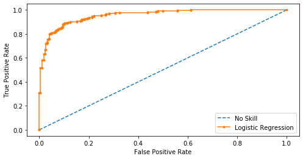

```python
# plot AUC curve
ROC_AUC_curve(model=lr_model,model_name="Logistic Regression")
```

```python
# printing the coefficients of LR model
lr_coefficients=OrderedDict(sorted(zip(X.columns,grid_lr.best_estimator_.coef_[0]),reverse=True,key=lambda x:x[1]))
```

```python
# printing the coefficients
pd.Series(lr_coefficients)
```

```
scene_transition_boundary_prediction_lag1    3.804769
scene_transition_boundary_prediction         3.171408
action_230_lag1                              0.160696
action_383                                   0.109977
action_137_lag1                              0.106804
                                               ...
place_758_lag1                              -0.235618
place_1447                                  -0.243916
place_564                                   -0.259082
place_1                                     -0.320020
place_1008                                  -0.340706
Length: 7170, dtype: float64
```

## 3.3.3) Linear Support Vector Machine

- We have implemented the Linear Support Vector Machine model here
- We have used a 5 folds cross validation grid search to perform the hyper parameter tuning
- After this, we have printed the classification report for our model on training and testing data in order to get a sense of how well our model is performing in terms of precision, recall, f1-score and accuracy
- We have not generated an AUC-ROC curve as SVM model does not predict the probability of the target class labels

```python
# initializing the linear SVC model
lsvm = LinearSVC(random_state=16)
```

#### Hyper-paramater tuning using GridSearch:

- C: This is the cost parameter. It is used for regularization and represents the penalty associated with misclassification. Higher C means lower bias but risk of overfitting. It also means higher complexity of decision boundary and higher number of support vectors. Similarly, lower C means higher bias but lower variance
- penalty: This represents the penalty as l1 and l2 regularisation parameter. The l1 and l2 both penalize the points and make the models less susceptible to outliers and improve its overall generalization.
- loss: Specifies the loss function. ‘hinge’ is the standard SVM loss (used e.g. by the SVC class) while ‘squared_hinge’ is the square of the hinge loss.
- n_jobs: This is a hyper-parameter used for the Grid search. n_jobs=-1 means that the computation will be dispatched on all the CPUs of the computer

```python
# Performing grid search to find the best hyper-parameters
param_grid_lsvm = { 'C':[.005,.01,.1,.2,.4,.8],
              'penalty':['l1', 'l2'],
              'loss': ['hinge', 'square_hinge']
              }
```

```python
# Using 5 fold cross validation and evaluation metric as Recall
grid_lsvm = GridSearchCV(lsvm, param_grid_lsvm, cv=5, scoring='recall', n_jobs=-1, verbose=1)
```

```python
# Fitting linear svc model
lsvm_model = grid_lsvm.fit(X_train, y_train)
```

```
Fitting 5 folds for each of 24 candidates, totalling 120 fits
```

```
[Parallel(n_jobs=-1)]: Using backend LokyBackend with 4 concurrent workers.
[Parallel(n_jobs=-1)]: Done  42 tasks      | elapsed:  1.5min
[Parallel(n_jobs=-1)]: Done 120 out of 120 | elapsed:  4.0min finished
```

```python
# printing the best hyper-parameters
lsvm_best_params = grid_lsvm.best_params_
print(lsvm_best_params)
```

```
{'C': 0.005, 'loss': 'hinge', 'penalty': 'l2'}
```

```python
# Printing classification report for predictions made by model on training dataset
print(classification_report(lsvm_model.predict(X_train),y_train))
```

```
              precision    recall  f1-score   support

           0       0.98      0.98      0.98       618
           1       0.98      0.98      0.98       618

    accuracy                           0.98      1236
   macro avg       0.98      0.98      0.98      1236
weighted avg       0.98      0.98      0.98      1236
```

```python
# Printing classification report for predictions made by model on validation dataset
print(classification_report(lsvm_model.predict(X_test),y_test))
```

```
              precision    recall  f1-score   support

           0       0.75      0.74      0.75       265
           1       0.75      0.75      0.75       266

    accuracy                           0.75       531
   macro avg       0.75      0.75      0.75       531
weighted avg       0.75      0.75      0.75       531
```

## 3.3.4) ANN - Artificial Neural Network - 1 Hidden Layer

- We have implemented the Artificial Neural Network model with 1 hidden layers here
- The ANN1 model contains an initial sequential layer followed by the dense hidden layer using activation function as 'relu' and 20 nodes followed by dense output layer that uses 'sigmoid' as the activation function in order to predict the binary labels for output class.
- The input shape is the total number of features present in the training data i.e. 7170
- The hidden layer contains 20 nodes of perceptrons
- We have used the loss function as 'binary_crossentropy', optimizer as 'adam' and metrics as 'accuracy' to implement a deep learning network with 1 hidden layers
- We have used epochs=30 and batch_size=20 for the hyperparameter tuning of the model and have calculated the loss and accuracy for both train and testing data for each epoch
- After this, we have printed the classification report for our model on training data, validation data in order to get a sense of how well our model is performing in terms of precision, recall, f1-score and accuracy
- We have generated an AUC-ROC curve as ANN1 model that predicts the probability of the target class labels

```python
# initializing the ANN1 model
ann1 = Sequential()
ann1.add(Dense(20, activation='relu', input_shape=(7170,)))
ann1.add(Dense(1, activation='sigmoid', input_shape=(20,)))
```

```python
# compiling ANN1 model
ann1.compile(loss='binary_crossentropy', optimizer='adam', metrics=['accuracy'])
```

```python
# fitting ANN1 model
ann1.fit(X_train, y_train, epochs=30, batch_size=20, verbose=1,validation_data=(X_test,y_test))
```

```
Train on 1236 samples, validate on 531 samples
```

```
<keras.callbacks.callbacks.History at 0x7fa28a5ace10>
```

```python
# Printing classification report for predictions made by model on training dataset
print(classification_report(y_true=y_train,y_pred=(ann1.predict(X_train)>0.5).astype(int)))
```

```
              precision    recall  f1-score   support

           0       0.50      1.00      0.67       620
           1       0.00      0.00      0.00       616

    accuracy                           0.50      1236
   macro avg       0.25      0.50      0.33      1236
weighted avg       0.25      0.50      0.34      1236
```

```python
# Printing classification report for predictions made by model on validation dataset
print(classification_report(y_true=y_test,y_pred=(ann1.predict(X_test)>0.5).astype(int)))
```

```
              precision    recall  f1-score   support

           0       0.50      1.00      0.66       263
           1       0.00      0.00      0.00       268

    accuracy                           0.50       531
   macro avg       0.25      0.50      0.33       531
weighted avg       0.25      0.50      0.33       531
```

```
No Skill: ROC AUC=0.500
Decision Tree: ROC AUC=0.498
```

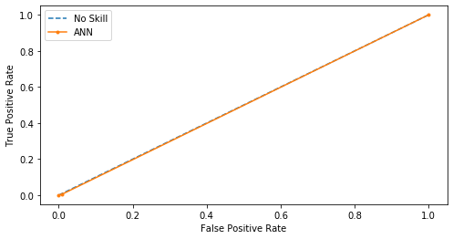

```python
# plot AUC curve
ROC_AUC_curve_upgraded(model=ann1,model_name="ANN")
```

## 3.3.5) Conclusion for Models with boundary prediction as feature and with single lag for semantic features

```python
# Creating a summary table for the model names, their recall, auc, accuracy scores and their best hyper parameters
best_models_3 = pd.DataFrame({"Algorithm":["LR","RF","ANN", "LSVM"], "Recall":[89,77,50,75],
                            "AUC":[95.5,85.7,50,'-'], 'Accuracy':[89,77,50,75],
                            'Precision':[90,79,50,75],
                            'F1-Score':[89,78,50,75]
                            })
```

```python
# Printing the best_models summary table sorted by F1-scores
best_models_3.sort_values(by="F1-Score",ascending=False)
```

|  | Algorithm | Recall | AUC | Accuracy | Precision | F1-Score |
| --- | --- | --- | --- | --- | --- | --- |
| 0 | LR | 89 | 95.5 | 89 | 90 | 89 |
| 1 | RF | 77 | 85.7 | 77 | 79 | 78 |
| 3 | LSVM | 75 | - | 75 | 75 | 75 |
| 2 | ANN | 50 | 50 | 50 | 50 | 50 |

## 3.4) Models without boundary prediction feature and with single lag for all semantic feature

- Here, we have implemented machine learning models on the dataset does not contain the feature - scene_transition_boundary_prediction
- The dataset also contains the lagged features

### Train-Test Split

```python
# Define X & y for the split
X = df_data_no_boundary_prediction_lag.drop('scene_transition_boundary_ground_truth', axis=1)
y = df_data_no_boundary_prediction_lag['scene_transition_boundary_ground_truth']
```

```python
# print head
X.head()
```

|  | place_0 | place_1 | place_2 | place_3 | place_4 | place_5 | place_6 | place_7 | place_8 | place_9 | ... | audio_502_lag1 | audio_503_lag1 | audio_504_lag1 | audio_505_lag1 | audio_506_lag1 | audio_507_lag1 | audio_508_lag1 | audio_509_lag1 | audio_510_lag1 | audio_511_lag1 |
| --- | --- | --- | --- | --- | --- | --- | --- | --- | --- | --- | --- | --- | --- | --- | --- | --- | --- | --- | --- | --- | --- |
| 1 | 0.213749 | 0.332000 | 0.142420 | 0.727351 | 1.186241 | 1.012456 | 0.181527 | 0.368308 | 0.181662 | 0.329417 | ... | -0.026605 | -0.023630 | -0.030976 | -0.021092 | -0.040983 | -0.005209 | -0.015622 | -0.018565 | -0.040693 | -0.043941 |
| 2 | 0.354128 | 0.639288 | 1.112100 | 0.059886 | 0.751858 | 0.348241 | 1.329029 | 0.355326 | 0.109889 | 0.464578 | ... | 0.006189 | 0.010023 | -0.029374 | 0.013504 | -0.058221 | 0.026287 | -0.049740 | -0.009002 | -0.028123 | -0.012860 |
| 3 | 0.018294 | 0.468095 | 0.124534 | 0.133849 | 0.156831 | 0.167848 | 0.417986 | 0.357649 | 0.140577 | 0.463034 | ... | -0.001303 | 0.004692 | -0.028627 | 0.009372 | -0.039274 | -0.022958 | -0.014214 | 0.008701 | -0.037563 | -0.038954 |
| 4 | 0.035420 | 0.968036 | 1.128158 | 0.047241 | 0.629714 | 0.197887 | 1.623528 | 0.578731 | 0.083444 | 0.565098 | ... | -0.014169 | -0.012023 | -0.017683 | -0.011584 | -0.000107 | -0.004316 | -0.009532 | -0.011385 | 0.007650 | 0.013937 |
| 5 | 0.275402 | 0.929346 | 0.527408 | 0.776896 | 0.245464 | 0.098361 | 0.585843 | 0.434912 | 0.000932 | 1.086755 | ... | -0.001574 | -0.002463 | -0.028059 | 0.001644 | -0.054553 | 0.004318 | -0.013977 | -0.001678 | -0.064567 | -0.068966 |

5 rows × 7168 columns

```python
# print shape
X.shape
```

```
(1767, 7168)
```

```python
# 70-30 train-validation split
X_train, X_test, y_train, y_test = train_test_split(X, y, test_size=0.3, random_state=16)
```

## 3.4.1) Random Forest

- We have implemented the Random Forest Clasifier model here
- We have used a 3 folds cross validation grid search to perform the hyper parameter tuning
- After this, we have printed the classification report for our model on training data and testing data in order to get a sense of how well our model is performing in terms of precision, recall, f1-score and accuracy
- We have also generated an AUC-ROC curve for RF model

```python
# initializing the RF model
rf=RandomForestClassifier(random_state=16,n_jobs=-1)
```

#### Hyper-paramater tuning using GridSearch:

- max_depth: This is the maximum depth till which the tree will keep on splitting. It ensures that the tree does not overfit the data
- max_features: The max_features is the number of features that will be used for making a single tree. For eg using "sqrt", the tree uses the square root of the number of total features in the data. Using auto is the same as making use of sqrt. The other values can be specified using the int(number of features to be used less than the total features), log, and a proportion of the features to be used
- min_samples_leaf: The minimum number of samples that should be there in leaf node. If the number is less, then the leaf node is pruned
- min_samples_split: The number of samples that should be present in the node for it to be split further
- n_estimators:This is an important tuning parameter for the Random Forest model. It is the number of trees to be used for predicting the result
- n_jobs: This is a hyper-parameter used for the Grid search. n_jobs=-1 means that the computation will be dispatched on all the CPUs of the computer

```python
# Performing grid search to find the best hyper-parameters
param_grid_rf = {'max_depth': [1,25,10],
            'max_features': ['auto', 'sqrt'],
            'min_samples_leaf': [10,20,30],
             'min_samples_split': [10,20,30],
             'n_estimators': [5,15,30]}
```

```python
# Using 5 fold cross validation and evaluation metric as Recall
grid_rf= GridSearchCV(rf, param_grid_rf, cv=3, scoring='recall', n_jobs=-1, verbose=1)
```

```python
# Fitting RF model
rf_model = grid_rf.fit(X_train, y_train)
```

```
Fitting 3 folds for each of 162 candidates, totalling 486 fits
```

```
[Parallel(n_jobs=-1)]: Using backend LokyBackend with 4 concurrent workers.
[Parallel(n_jobs=-1)]: Done  42 tasks      | elapsed:    8.2s
[Parallel(n_jobs=-1)]: Done 192 tasks      | elapsed:   27.3s
[Parallel(n_jobs=-1)]: Done 442 tasks      | elapsed:  1.1min
[Parallel(n_jobs=-1)]: Done 486 out of 486 | elapsed:  1.2min finished
```

```python
# printing the best hyper-parameters
rf_model_best_params = grid_rf.best_params_
print(rf_model_best_params)
```

```
{'max_depth': 25, 'max_features': 'auto', 'min_samples_leaf': 30, 'min_samples_split': 10, 'n_estimators': 30}
```

```python
# Printing classification report for predictions made by model on training dataset
print(classification_report(rf_model.predict(X_train),y_train))
```

```
              precision    recall  f1-score   support

           0       0.86      0.89      0.87       603
           1       0.89      0.86      0.88       633

    accuracy                           0.87      1236
   macro avg       0.87      0.87      0.87      1236
weighted avg       0.87      0.87      0.87      1236
```

```python
# Printing classification report for predictions made by model on validation dataset
print(classification_report(rf_model.predict(X_test),y_test))
```

```
              precision    recall  f1-score   support

           0       0.70      0.72      0.71       257
           1       0.73      0.72      0.72       274

    accuracy                           0.72       531
   macro avg       0.72      0.72      0.72       531
weighted avg       0.72      0.72      0.72       531
```

```
No Skill: ROC AUC=0.500
Model: ROC AUC=0.794
```

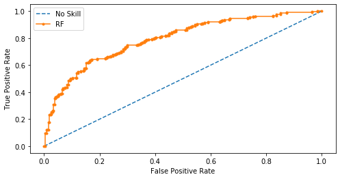

```python
# ROC curve for RF model
ROC_AUC_curve(model=rf_model,model_name="RF")
```

#### Feature Importance plot for RF

```python
# creating a new dataframe to store the features and their respective importance values
feature_imp = pd.DataFrame(rf_model.best_estimator_.feature_importances_, index=X_train.columns,
columns=['importance']).sort_values('importance', ascending=False)
feature_imp['features'] = feature_imp.index
feature_imp
```

|  | importance | features |
| --- | --- | --- |
| place_1789 | 0.017564 | place_1789 |
| audio_396_lag1 | 0.012347 | audio_396_lag1 |
| audio_364_lag1 | 0.012156 | audio_364_lag1 |
| place_1229 | 0.009412 | place_1229 |
| place_1013_lag1 | 0.008675 | place_1013_lag1 |
| ... | ... | ... |
| cast_423 | 0.000000 | cast_423 |
| cast_422 | 0.000000 | cast_422 |
| cast_421 | 0.000000 | cast_421 |
| cast_420 | 0.000000 | cast_420 |
| audio_511_lag1 | 0.000000 | audio_511_lag1 |

7168 rows × 2 columns

```python
# top 10 features
feature_imp_10 = feature_imp.head(10)
```

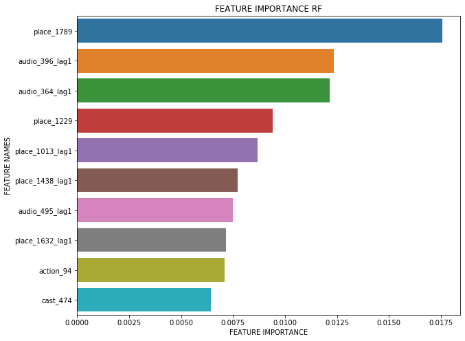

```python
# Plotting Feature Importance graph
plt.figure(figsize=(10,8))

sns.barplot(x=feature_imp_10['importance'], y=feature_imp_10['features'])

plt.title('FEATURE IMPORTANCE RF')
plt.xlabel('FEATURE IMPORTANCE')
plt.ylabel('FEATURE NAMES')
```

## 3.4.2) Logistic Regression

- We have implemented the Logistic Regression classifier model here
- We have used a 5 folds cross validation grid search to perform the hyper-parameter tuning
- After this, we have printed the classification report for our model on training data and testing data in order to get a sense of how well our model is performing in terms of precision, recall, f1-score and accuracy and to see if our model is overfitting on the training data
- We have also generated an AUC-ROC curve for the Logistic Regression model

```python
# initializing the LR model
lr=LogisticRegression(random_state=16,solver="liblinear")
```

#### Hyper-paramater tuning using GridSearch:

- C: This is the cost parameter. It is the inverse of the lambda. Smaller value specify more regularization
- Penalty: The types of penalty that can be used are l1 and l2. The l1 penalty has the characteristics of eliminating features by making its co-efficient 0. The l2 penalty does not eliminate features but it penalizes the effect of less useful features and makes their co-efficient close to 0

```python
# Performing grid search to find the best hyper-parameters
param_grid_lr = {
              'C': [.001,.005,.01,0.1],
              'penalty': ['l1', 'l2']
              }
```

```python
# Using 2 fold cross validation and evaluation metric as Recall
grid_lr = GridSearchCV(lr, param_grid_lr, scoring='recall', cv=5, n_jobs=-1, verbose=1)
```

```python
# Fitting LR model
lr_model = grid_lr.fit(X_train, y_train)
```

```
Fitting 5 folds for each of 8 candidates, totalling 40 fits
```

```
[Parallel(n_jobs=-1)]: Using backend LokyBackend with 4 concurrent workers.
[Parallel(n_jobs=-1)]: Done  40 out of  40 | elapsed:   29.8s finished
```

```python
# printing best hyper-parameters for model
lr_best_params = grid_lr.best_params_
print(lr_best_params)
```

```
{'C': 0.001, 'penalty': 'l2'}
```

```python
# Printing classification report for predictions made by model on training dataset
print(classification_report(lr_model.predict(X_train),y_train))
```

```
              precision    recall  f1-score   support

           0       0.83      0.84      0.83       609
           1       0.84      0.83      0.84       627

    accuracy                           0.84      1236
   macro avg       0.84      0.84      0.84      1236
weighted avg       0.84      0.84      0.84      1236
```

```python
# Printing classification report for predictions made by model on test dataset
print(classification_report(lr_model.predict(X_test),y_test))
```

```
              precision    recall  f1-score   support

           0       0.73      0.76      0.75       253
           1       0.78      0.75      0.76       278

    accuracy                           0.76       531
   macro avg       0.75      0.76      0.75       531
weighted avg       0.76      0.76      0.76       531
```

```
No Skill: ROC AUC=0.500
Model: ROC AUC=0.835
```

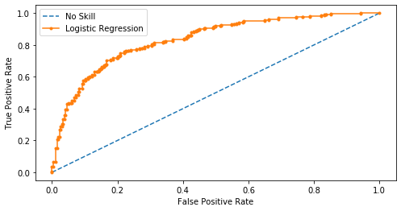

```python
# plot AUC curve
ROC_AUC_curve(model=lr_model,model_name="Logistic Regression")
```

```python
# printing the coefficients of LR model
lr_coefficients=OrderedDict(sorted(zip(X.columns,grid_lr.best_estimator_.coef_[0]),reverse=True,key=lambda x:x[1]))
```

```python
# printing the coefficients
pd.Series(lr_coefficients)
```

```
action_230_lag1    0.031883
action_458_lag1    0.028450
action_331         0.026307
action_37          0.025958
action_103_lag1    0.025590
                     ...
action_494        -0.027909
action_168_lag1   -0.028578
place_879_lag1    -0.029041
action_168        -0.029073
action_320_lag1   -0.029267
Length: 7168, dtype: float64
```

## 3.4.3) Linear Support Vector Machine

- We have implemented the Linear Support Vector Machine model here
- We have used a 5 folds cross validation grid search to perform the hyper parameter tuning
- After this, we have printed the classification report for our model on training and testing data in order to get a sense of how well our model is performing in terms of precision, recall, f1-score and accuracy
- We have not generated an AUC-ROC curve as SVM model does not predict the probability of the target class labels

```python
# initializing the linear SVC model
lsvm = LinearSVC(random_state=16)
```

#### Hyper-paramater tuning using GridSearch:

- C: This is the cost parameter. It is used for regularization and represents the penalty associated with misclassification. Higher C means lower bias but risk of overfitting. It also means higher complexity of decision boundary and higher number of support vectors. Similarly, lower C means higher bias but lower variance
- penalty: This represents the penalty as l1 and l2 regularisation parameter. The l1 and l2 both penalize the points and make the models less susceptible to outliers and improve its overall generalization.
- loss: Specifies the loss function. ‘hinge’ is the standard SVM loss (used e.g. by the SVC class) while ‘squared_hinge’ is the square of the hinge loss.
- n_jobs: This is a hyper-parameter used for the Grid search. n_jobs=-1 means that the computation will be dispatched on all the CPUs of the computer

```python
# Performing grid search to find the best hyper-parameters
param_grid_lsvm = { 'C':[.005,.01,.1,.2,.4,.8],
              'penalty':['l1', 'l2'],
              'loss': ['hinge', 'square_hinge']
              }
```

```python
# Using 5 fold cross validation and evaluation metric as Recall
grid_lsvm = GridSearchCV(lsvm, param_grid_lsvm, cv=5, scoring='recall', n_jobs=-1, verbose=1)
```

```python
# Fitting linear svc model
lsvm_model = grid_lsvm.fit(X_train, y_train)
```

```
Fitting 5 folds for each of 24 candidates, totalling 120 fits
```

```
[Parallel(n_jobs=-1)]: Using backend LokyBackend with 4 concurrent workers.
[Parallel(n_jobs=-1)]: Done  42 tasks      | elapsed:   47.9s
[Parallel(n_jobs=-1)]: Done 120 out of 120 | elapsed:  2.6min finished
```

```python
# printing the best hyper-parameters
lsvm_best_params = grid_lsvm.best_params_
print(lsvm_best_params)
```

```
{'C': 0.005, 'loss': 'hinge', 'penalty': 'l2'}
```

```python
# Printing classification report for predictions made by model on training dataset
print(classification_report(lsvm_model.predict(X_train),y_train))
```

```
              precision    recall  f1-score   support

           0       0.97      0.97      0.97       624
           1       0.97      0.97      0.97       612

    accuracy                           0.97      1236
   macro avg       0.97      0.97      0.97      1236
weighted avg       0.97      0.97      0.97      1236
```

```python
# Printing classification report for predictions made by model on validation dataset
print(classification_report(lsvm_model.predict(X_test),y_test))
```

```
              precision    recall  f1-score   support

           0       0.72      0.70      0.71       271
           1       0.70      0.72      0.71       260

    accuracy                           0.71       531
   macro avg       0.71      0.71      0.71       531
weighted avg       0.71      0.71      0.71       531
```

## 3.4.4) ANN - Artificial Neural Network - 1 Hidden Layer

- We have implemented the Artificial Neural Network model with 1 hidden layers here
- The ANN1 model contains an initial sequential layer followed by the dense hidden layer using activation function as 'relu' and 20 nodes followed by dense output layer that uses 'sigmoid' as the activation function in order to predict the binary labels for output class.
- The input shape is the total number of features present in the training data i.e. 7168
- The hidden layer contains 20 nodes of perceptrons
- We have used the loss function as 'binary_crossentropy', optimizer as 'adam' and metrics as 'accuracy' to implement a deep learning network with 1 hidden layers
- We have used epochs=30 and batch_size=20 for the hyperparameter tuning of the model and have calculated the loss and accuracy for both train and testing data for each epoch
- After this, we have printed the classification report for our model on training data, validation data in order to get a sense of how well our model is performing in terms of precision, recall, f1-score and accuracy
- We have generated an AUC-ROC curve as ANN1 model that predicts the probability of the target class labels

```python
# initializing the ANN1 model
ann1 = Sequential()
ann1.add(Dense(20, activation='relu', input_shape=(7168,)))
ann1.add(Dense(1, activation='sigmoid', input_shape=(20,)))
```

```python
# compiling ANN1 model
ann1.compile(loss='binary_crossentropy', optimizer='adam', metrics=['accuracy'])
```

```python
# fitting ANN1 model
ann1.fit(X_train, y_train, epochs=30, batch_size=20, verbose=1,validation_data=(X_test,y_test))
```

```
Train on 1236 samples, validate on 531 samples
```

```
<keras.callbacks.callbacks.History at 0x7fa201c45b90>
```

```python
# Printing classification report for predictions made by model on training dataset
print(classification_report(y_true=y_train,y_pred=(ann1.predict(X_train)>0.5).astype(int)))
```

```
              precision    recall  f1-score   support

           0       0.50      1.00      0.67       620
           1       0.00      0.00      0.00       616

    accuracy                           0.50      1236
   macro avg       0.25      0.50      0.33      1236
weighted avg       0.25      0.50      0.34      1236
```

```python
# Printing classification report for predictions made by model on validation dataset
print(classification_report(y_true=y_test,y_pred=(ann1.predict(X_test)>0.5).astype(int)))
```

```
              precision    recall  f1-score   support

           0       0.50      1.00      0.66       263
           1       0.00      0.00      0.00       268

    accuracy                           0.50       531
   macro avg       0.25      0.50      0.33       531
weighted avg       0.25      0.50      0.33       531
```

```
No Skill: ROC AUC=0.500
Decision Tree: ROC AUC=0.502
```

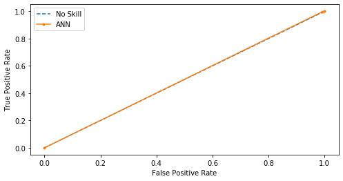

```python
# plot AUC curve
ROC_AUC_curve_upgraded(model=ann1,model_name="ANN")
```

## 3.4.5) Conclusion for Models without boundary prediction as feature and with single lag for semantic features

```python
# Creating a summary table for the model names, their recall, auc, accuracy scores and their best hyper parameters
best_models_4 = pd.DataFrame({"Algorithm":["LR","RF","ANN","LSVM"], "Recall":[75,72,50,72],
                            "AUC":[83.5,79.4,50,'-'], 'Accuracy':[76,72,50,71],
                            'Precision':[78,73,50,70],
                            'F1-Score':[76,72,50,71]
                            })
```

```python
# Printing the best_models summary table sorted by F1-scores
best_models_4.sort_values(by="F1-Score",ascending=False)
```

|  | Algorithm | Recall | AUC | Accuracy | Precision | F1-Score |
| --- | --- | --- | --- | --- | --- | --- |
| 0 | LR | 75 | 83.5 | 76 | 78 | 76 |
| 1 | RF | 72 | 79.4 | 72 | 73 | 72 |
| 3 | LSVM | 72 | - | 71 | 70 | 71 |
| 2 | ANN | 50 | 50 | 50 | 50 | 50 |